# هوش مصنوعی

## پروژه چهارم - یادگیری ماشین

### دکتر فدایی - دکتر مرادی

### محیا قینی -810196615

###### آذر 1399

## هدف پروژه

یکی از مسائل مهم و پرکاربرد در حوزه هوش مصنوعی مسائل تخمین زن هستند. برای این مسائل به کمک یکسری از مدل ها agent را با کمک داده های train آموزش می دهیم و agent با کمک این آموزش ها داده هدف test را می تواند تخمین زند. بدین جهت مدل های زیادی وجود دارد که در طول این پروژه با تعدادی از آن ها کار خواهیم کرد. پیاده سازی این مدل ها با کمک کتابخانه Scikit-Learn صورت میگیرد.

## صورت مسئله

به ما مجموعه ای داده که برگرفته از سایت kaggle هستند؛ داده شده است. حال از ما خواسته شده با توجه به مدل های یادگیری ماشین و داده هایی که داریم؛ به گونه ای ماشین را آموزش دهیم که بتواند با خطای قابل قبولی هدف را برای مجموعه جدیدی از داده ها تخمین زند. البته برای تست مدل هایمان داده ای که همراه با مقدار هدف داریم را به دو قسمت آموزش و ارزیابی تقسیم می کنیم.

## کتابخانه های استفاده شده در حل مسئله

همانطور که می دانیم در پایتون کتابخانه های کاربردی و زیادی برای راحت تر شدن تحلیل ها و کار با داده ها وجود دارد. برای این مسئله از کتابخانه های زیر استفاده شده است: - کتابخانه pandas:  
این کتابخانه به جهت کار و مدیریت دیتافریم ها نیاز است.  
- کتابخانه numpy:  
این کتابخانه برای عملیات لگاریتم و دسته بندی داده ها به دو دسته آموزش و ارزیابی نیاز است.  
- کتابخانه seaborn و matplotlib.pyplot:  
این دو کتابخانه برای نمایش نمودار ها و جهت تحلیل بهتر تصمیماتی که میگیریم به کار می روند.  
- کتابخانه Scikit-Learn:  
این کتابخانه در ادامه بسیار به کار خواهد رفت و برای پیاده سازی مدل های یادگیری مختلف بسیار کاربردی است.

```python
import pandas as panda
import numpy as num
import matplotlib.pyplot as mplot
import seaborn as sb
```

## دیتای داده شده

داده ها به تفصیل در فاز اول بررسی می شوند اما در کل :  
دو دسته داده به ما داده شده است.در ادامه این دو دسته را میبینیم:  
1) داده جهت train:  
این دسته از داده 1460 سطر و 81 ستون دارند. که ستون ها ویژگی های گوناگونی هست که هر خانه دارد به همراه قیمت فروش آن خانه. از قسمتی از این داده به جهت آموزش ماشین و آماده سازی مدل ها استفاده می شود و قسمت دیگر به جهت ارزیابی مدل تهیه شده.  
2) داده جهت test:  
این دسته از داده 1460 سطر و 80 ستون دارند. که ستون ها ویژگی های گوناگونی هست که هر خانه دارد و باید قیمت فروش خانه را تخمین بزنیم. نتیجه حاصل از این تخمین را می توانیم برای شرکت در مسابقه سایت kaggle به کار ببریم.

```python
#Phase 0 - visualization & EDA
```

## فاز صفر: Visualizatio and EDA

زمانی که می خواهیم یک مدل یادگیری پیاده سازی کنیم، حتماً لازم است داده ها را خوب بشناسیم و از جهات مختلف آن را بررسی کنیم و به دنبال گونه ای ارتباط بین صفات مختلف در آنها باشیم. در این فاز این عملیات انجام می شوند. این فاز اهمیت زیادی دارد چون هر چقدر شناختمان از داده ها بیشتر باشد هدفمند تر و دقیق تر میتوانیم ماشینمان را آموزش دهیم. در ادامه تعدادی از عملیات که به ما دید مناسب تری نسبت به ویژگی ها می دهند را بررسی می کنیم.

برای راحت تر شدن پیاده سازی و خوانایی بیشتر تعدادی تابع ابتدای هر فاز تعریف میشوند که در طول فاز آنها استفاده میکنیم.

```python
#Functions
def readData(fileName):
    df = panda.read_csv(fileName)
    return df
def getPercentageOfMissingValues(dataFrame):
    data = (dataFrame.isna().sum()/len(dataFrame))*100
    df = panda.DataFrame(list(zip(dataFrame.columns, data)), columns = ["Feature","Percentage of missing values"])
    return df
def getLogTarget(dataFrame, target):
    df = dataFrame[:]
    df[target] = num.log(dataFrame[target])
    return df
def getObjects(dataFrame):
    objects = []
    for attribute in dataFrame.columns:
        if dataFrame[attribute].dtype == object:
            objects.append(attribute)
    return objects
def getNum(dataFrame):
    num = []
    for attribute in dataFrame.columns:
        if dataFrame[attribute].dtype != object:
            num.append(attribute)
    return num
```

**1) ساختار کلی داده ها را با متد های describe و info از پکیج Pandas بررسی کنید.**  
اولین قدم شناخت داده ها بررسی ساختار آنها از نظر نوع داده ها، تعداد از دست رفته، میانگین هر دسته و از این موارد است که این امکان با توابع ذکر شده ممکن است.

با نگاه اول به dataframe حاصل از خواندن داده ها متوجه می شویم داده ها 81 ستون دارند بدین معنا که برای هر داده با 81 ویژگی سروکار خواهیم داشت. اینجا برای اشغال جای کمتر تنها با کمک head پنج سطر اول داده نمایش داده شده اند اما در کل داده ها 1460 سطر دارند.

```python
#0.1
inData = readData("train.csv")
inData.head()
```

|  | Id | MSSubClass | MSZoning | LotFrontage | LotArea | Street | Alley | LotShape | LandContour | Utilities | ... | PoolArea | PoolQC | Fence | MiscFeature | MiscVal | MoSold | YrSold | SaleType | SaleCondition | SalePrice |
| --- | --- | --- | --- | --- | --- | --- | --- | --- | --- | --- | --- | --- | --- | --- | --- | --- | --- | --- | --- | --- | --- |
| 0 | 1 | 60 | RL | 65.0 | 8450 | Pave | NaN | Reg | Lvl | AllPub | ... | 0 | NaN | NaN | NaN | 0 | 2 | 2008 | WD | Normal | 208500 |
| 1 | 2 | 20 | RL | 80.0 | 9600 | Pave | NaN | Reg | Lvl | AllPub | ... | 0 | NaN | NaN | NaN | 0 | 5 | 2007 | WD | Normal | 181500 |
| 2 | 3 | 60 | RL | 68.0 | 11250 | Pave | NaN | IR1 | Lvl | AllPub | ... | 0 | NaN | NaN | NaN | 0 | 9 | 2008 | WD | Normal | 223500 |
| 3 | 4 | 70 | RL | 60.0 | 9550 | Pave | NaN | IR1 | Lvl | AllPub | ... | 0 | NaN | NaN | NaN | 0 | 2 | 2006 | WD | Abnorml | 140000 |
| 4 | 5 | 60 | RL | 84.0 | 14260 | Pave | NaN | IR1 | Lvl | AllPub | ... | 0 | NaN | NaN | NaN | 0 | 12 | 2008 | WD | Normal | 250000 |

5 rows × 81 columns

با کمک تابع describe متوجه می شویم 38 ستون از ویژگی ها عددی هستند که خصوصیات مختلف آنها از جمله تعداد، میانگین، واریانس و ... آنها در پایین قابل مشاهده است. با کمک تعداد هر ستون می توان تعداد داده های از دست رفته هر ویژگی را متوجه شد البته بررسی دقیق تر این مورد با کمک تابع info در ادامه صورت میگیرد.

```python
inData.describe()
```

|  | Id | MSSubClass | LotFrontage | LotArea | OverallQual | OverallCond | YearBuilt | YearRemodAdd | MasVnrArea | BsmtFinSF1 | ... | WoodDeckSF | OpenPorchSF | EnclosedPorch | 3SsnPorch | ScreenPorch | PoolArea | MiscVal | MoSold | YrSold | SalePrice |
| --- | --- | --- | --- | --- | --- | --- | --- | --- | --- | --- | --- | --- | --- | --- | --- | --- | --- | --- | --- | --- | --- |
| count | 1460.000000 | 1460.000000 | 1201.000000 | 1460.000000 | 1460.000000 | 1460.000000 | 1460.000000 | 1460.000000 | 1452.000000 | 1460.000000 | ... | 1460.000000 | 1460.000000 | 1460.000000 | 1460.000000 | 1460.000000 | 1460.000000 | 1460.000000 | 1460.000000 | 1460.000000 | 1460.000000 |
| mean | 730.500000 | 56.897260 | 70.049958 | 10516.828082 | 6.099315 | 5.575342 | 1971.267808 | 1984.865753 | 103.685262 | 443.639726 | ... | 94.244521 | 46.660274 | 21.954110 | 3.409589 | 15.060959 | 2.758904 | 43.489041 | 6.321918 | 2007.815753 | 180921.195890 |
| std | 421.610009 | 42.300571 | 24.284752 | 9981.264932 | 1.382997 | 1.112799 | 30.202904 | 20.645407 | 181.066207 | 456.098091 | ... | 125.338794 | 66.256028 | 61.119149 | 29.317331 | 55.757415 | 40.177307 | 496.123024 | 2.703626 | 1.328095 | 79442.502883 |
| min | 1.000000 | 20.000000 | 21.000000 | 1300.000000 | 1.000000 | 1.000000 | 1872.000000 | 1950.000000 | 0.000000 | 0.000000 | ... | 0.000000 | 0.000000 | 0.000000 | 0.000000 | 0.000000 | 0.000000 | 0.000000 | 1.000000 | 2006.000000 | 34900.000000 |
| 25% | 365.750000 | 20.000000 | 59.000000 | 7553.500000 | 5.000000 | 5.000000 | 1954.000000 | 1967.000000 | 0.000000 | 0.000000 | ... | 0.000000 | 0.000000 | 0.000000 | 0.000000 | 0.000000 | 0.000000 | 0.000000 | 5.000000 | 2007.000000 | 129975.000000 |
| 50% | 730.500000 | 50.000000 | 69.000000 | 9478.500000 | 6.000000 | 5.000000 | 1973.000000 | 1994.000000 | 0.000000 | 383.500000 | ... | 0.000000 | 25.000000 | 0.000000 | 0.000000 | 0.000000 | 0.000000 | 0.000000 | 6.000000 | 2008.000000 | 163000.000000 |
| 75% | 1095.250000 | 70.000000 | 80.000000 | 11601.500000 | 7.000000 | 6.000000 | 2000.000000 | 2004.000000 | 166.000000 | 712.250000 | ... | 168.000000 | 68.000000 | 0.000000 | 0.000000 | 0.000000 | 0.000000 | 0.000000 | 8.000000 | 2009.000000 | 214000.000000 |
| max | 1460.000000 | 190.000000 | 313.000000 | 215245.000000 | 10.000000 | 9.000000 | 2010.000000 | 2010.000000 | 1600.000000 | 5644.000000 | ... | 857.000000 | 547.000000 | 552.000000 | 508.000000 | 480.000000 | 738.000000 | 15500.000000 | 12.000000 | 2010.000000 | 755000.000000 |

8 rows × 38 columns

با کمک تابع info متوجه می شویم 38 ویژگی عددی(int و float) داریم و 43 ویژگی غیر عددی. همچنین برای هر ویژگی تعداد داده های از دست رفته را هم متوجه می شویم.

```python
inData.info()
```

```
<class 'pandas.core.frame.DataFrame'>
RangeIndex: 1460 entries, 0 to 1459
Data columns (total 81 columns):
 #   Column         Non-Null Count  Dtype
---  ------         --------------  -----
 0   Id             1460 non-null   int64
 1   MSSubClass     1460 non-null   int64
 2   MSZoning       1460 non-null   object
 3   LotFrontage    1201 non-null   float64
 4   LotArea        1460 non-null   int64
 5   Street         1460 non-null   object
 6   Alley          91 non-null     object
 7   LotShape       1460 non-null   object
 8   LandContour    1460 non-null   object
 9   Utilities      1460 non-null   object
```

[output cut: 73 more lines]

حال که تا حد ابتدایی با ساختار داده ها آشنا شدیم خوب است ویژگی ها را دسته بندی کنیم. ابتدا ویژگی های عددی و غیرعددی را به کل از هم جدا میکنیم. حال بررسی میکنیم طبق تعریف ویژگی ها که در فایل description کنار داده ها قرار دارد آیا NA در آنها معنای خاصی دارد یا نه. اگر داشت آنها را در دسته ای جدا قرار می دهیم. و سپس ویژگی هایی که مقدار گم شده دارند را هم جدا میکنیم.این جداسازی ها در مراحل بعد که می خوایم داده های گم شده را پر کنیم بسیار به کار خواهند آمد.

```python
#Classify features
categorical = getObjects(inData)
numerical = getNum(inData)
definedNaCols = ["Alley", "BsmtQual", "BsmtCond", "BsmtExposure",
                 "BsmtFinType1", "BsmtFinType2", "FireplaceQu",
                 "GarageType", "GarageFinish", "GarageQual", "GarageCond",
                 "PoolQC", "Fence", "MiscFeature"]
relatedToDefined = ["GarageYrBlt"]
nanObjectCols = ["MasVnrType", "Electrical"]
nanNumCols = ["LotFrontage", "MasVnrArea"]
```

**2) درصد داده های از دست رفته ی هر ویژگی را بدست آورید.**  
با کمک تابعی کلی برای هر ویژگی تعداد از دست رفته را تقسیم بر تعداد کل می کنیم و ضربدر صد می کنیم. البته برای ویژگی هایی که NA برای آنها معنایی خاص دارند درصد صفر را در نظر میگیریم. حاصل در یک dataframe ذخیره شده که برای تمیزی تنها 7 سطر اول آن در زیر نمایش داده شده است.

```python
#0.2
missingValuesPercent = getPercentageOfMissingValues(inData)
for f in definedNaCols:
    missingValuesPercent.loc[missingValuesPercent["Feature"] == f, "Percentage of missing values"] = 0.0
missingValuesPercent.head(7)
```

|  | Feature | Percentage of missing values |
| --- | --- | --- |
| 0 | Id | 0.000000 |
| 1 | MSSubClass | 0.000000 |
| 2 | MSZoning | 0.000000 |
| 3 | LotFrontage | 17.739726 |
| 4 | LotArea | 0.000000 |
| 5 | Street | 0.000000 |
| 6 | Alley | 0.000000 |

**3) نمودار وابستگی ویژگی ها به هم را رسم کنید. به نظرتان کدام ویژگی ها در تخمین قیمت خانه ها می توانند مفید باشند؟**  
اینجا با کمک تابع corr که کوتاه شده correlation هست ارتباط بین ویژگی ها و میزان آن را حساب میکنیم. که البته این کار برای ویژگی های عددی ممکن است. برای بررسی دقیق تر این ارتباطات نمودار مربوط به آن را با کمک heatmap رسم می کنیم و برای تشخیص راحت تر رنگ این ارتباطات نوع نمایش را coolwarm می گذاریم.

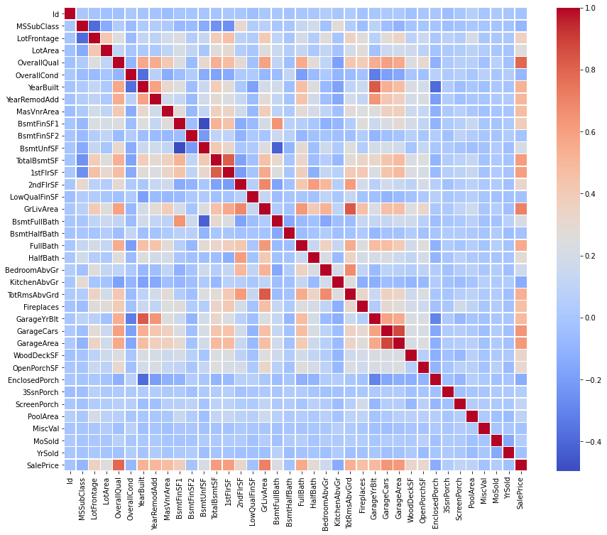

```python
#0.3
mplot.figure(figsize=(15, 12))
sb.heatmap(inData.corr(),square = True, linewidths = .5, cmap = "coolwarm")
```

حال برای بررسی دقیق تر ارتباط ویژگی ها با هدف و قیمت خانه دوازده ویژگی که بیشترین ارتباط را با قیمت خانه دارند جدا میکنیم و یکبار دیگر نمودار heatmap را می کشیم.

```python
topAttr = inData[inData.columns[:]].corr()['SalePrice'][:].sort_values(ascending=False)[:12].keys()
```

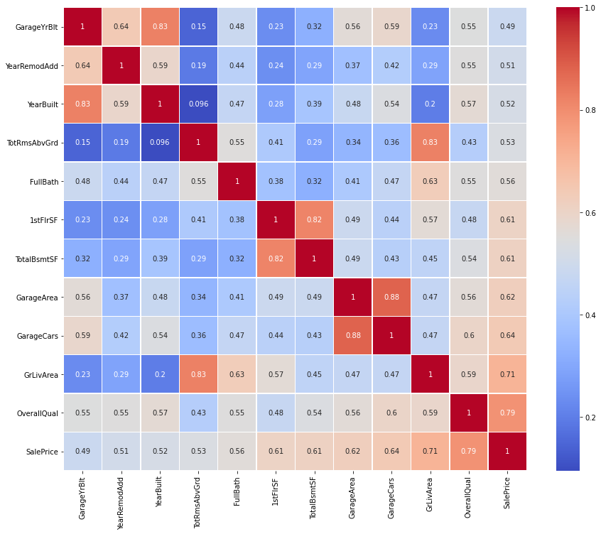

```python
maybeGoodAttr = inData[topAttr[::-1]]
mplot.figure(figsize=(15, 12))
sb.heatmap(maybeGoodAttr.corr(),square = True, annot=True, linewidths = .5, cmap = "coolwarm")
```

```python
numChosenAttributes = ["OverallQual", "GrLivArea", "GarageCars", "GarageArea", "TotalBsmtSF"]
```

در نهایت ویژگی های بالا به عنوان ویژگی هایی که بیشترین تاثیر بر قیمت خانه دارند انتخاب می شوند. البته GarageCars با توجه به اینکه با GarageArea هم رابطه بالایی دارد اطلاعات جدید زیادی را به ما نمی دهد.

**4) از قیمت خانه ها لگاریتم گرفته و دوباره نمودار وابستگی ویژگی ها را رسم کنید. آیا تفاوت وجود دارد؟ چرا؟**  
اینجا ابتدا از ستون هدف لگاریتم گرفتیم اما بعد از آن با dataframe جدید کاملاً مراحل قبل را تکرار کردیم. حاصل پایین قابل مشاهده است.

```python
#0.4::
logGoalData = getLogTarget(inData, "SalePrice")
logGoalData.head()
```

|  | Id | MSSubClass | MSZoning | LotFrontage | LotArea | Street | Alley | LotShape | LandContour | Utilities | ... | PoolArea | PoolQC | Fence | MiscFeature | MiscVal | MoSold | YrSold | SaleType | SaleCondition | SalePrice |
| --- | --- | --- | --- | --- | --- | --- | --- | --- | --- | --- | --- | --- | --- | --- | --- | --- | --- | --- | --- | --- | --- |
| 0 | 1 | 60 | RL | 65.0 | 8450 | Pave | NaN | Reg | Lvl | AllPub | ... | 0 | NaN | NaN | NaN | 0 | 2 | 2008 | WD | Normal | 12.247694 |
| 1 | 2 | 20 | RL | 80.0 | 9600 | Pave | NaN | Reg | Lvl | AllPub | ... | 0 | NaN | NaN | NaN | 0 | 5 | 2007 | WD | Normal | 12.109011 |
| 2 | 3 | 60 | RL | 68.0 | 11250 | Pave | NaN | IR1 | Lvl | AllPub | ... | 0 | NaN | NaN | NaN | 0 | 9 | 2008 | WD | Normal | 12.317167 |
| 3 | 4 | 70 | RL | 60.0 | 9550 | Pave | NaN | IR1 | Lvl | AllPub | ... | 0 | NaN | NaN | NaN | 0 | 2 | 2006 | WD | Abnorml | 11.849398 |
| 4 | 5 | 60 | RL | 84.0 | 14260 | Pave | NaN | IR1 | Lvl | AllPub | ... | 0 | NaN | NaN | NaN | 0 | 12 | 2008 | WD | Normal | 12.429216 |

5 rows × 81 columns

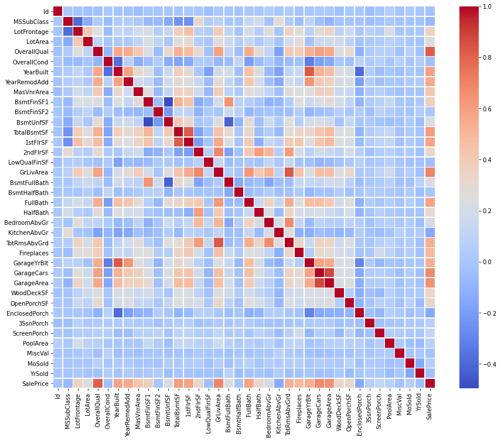

```python
mplot.figure(figsize=(15, 12))
sb.heatmap(logGoalData.corr(),square = True, linewidths = .5, cmap = "coolwarm")
```

```python
logTopAttr = logGoalData[logGoalData.columns[:]].corr()['SalePrice'][:].sort_values(ascending=False)[:12].keys()
```

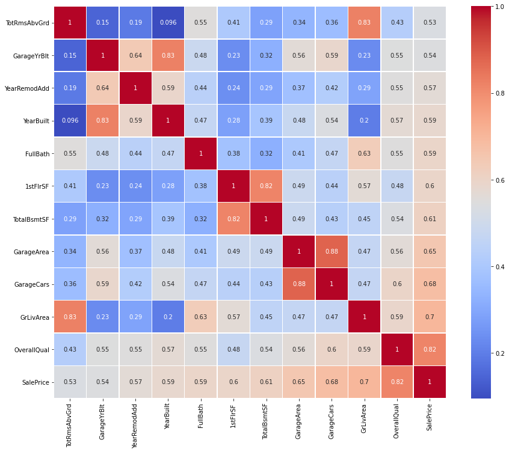

```python
maybeGoodAttr = logGoalData[logTopAttr[::-1]]
mplot.figure(figsize=(15, 12))
sb.heatmap(maybeGoodAttr.corr(),square = True, annot=True, linewidths = .5, cmap = "coolwarm")
```

```python
logChosenAttributes = ["OverallQual", "GrLivArea", "GarageCars", "GarageArea", "TotalBsmtSF"]
```

**5) آیا سوال 3 برای بررسی تمام ویژگی ها کافی است؟ چه ایرادی وجود دارد؟**  
خیر همانطور که در heatmap ها هم مشاهده می شود؛ تنها رابطه ویژگی های عددی با هم مشاهده می شود. دلیل هم این هست که تابع corr روی ویژگی های عددی اعمال میشودو ایرادی که وجود دارد این است که با کمک روش سوال 3 نمیتوان متوجه شد کدام ویژگی غیرعددی رابطه زیادی با هدف دارد و ویژگی های غیر عددی بررسی نمی شوند.

**6) ارتباط ویژگی های که در سوال سه نام بردید را با قیمت خانه ها دقیق تر بررسی کنید.**  
برای بررسی دقیق تر نمودارهای scatter و hexbin مربوط به رابطه هر ویژگی منتخب با قیمت خانه را رسم کردیم. نمودار های سمت چپ رابطه ویژگی با خود ویژگی هدف و نمودارهای سمت راست رابطه هر ویژگی با لگاریتم ویژگی هدف نشان می دهد. همانطور که میبینیم در نمودارهای سمت چپ روابط به صورت نمایی هستند اما در نمودارهای سمت راست این روابط حالت خطی دارند که در اثر همان لگاریتم گرفتن صورت میگیرد.  
همچنین نمودار hexbin هم برای نمایش رابطه دو متغیر عددی با حجم داده بالا به کار می رود. این نمودار صفحه را تبدیل به چند شش ضلعی می کند و براساس تعداد نقطه های تداخل دو متغیر که در هر شش ضلعی میافتد آن شش ضلعی رنگ می شود و هرچه نقاط بیشتر باشد پررنگ تر می شود.  
روابط ویژگی ها و نمایی و خطی بودن در نمودار scatter وضوح بیشتری دارد.

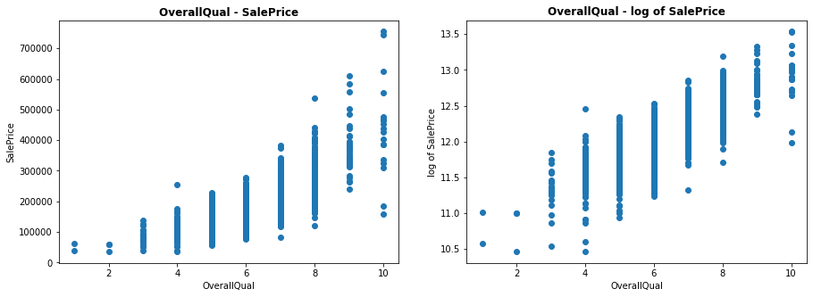

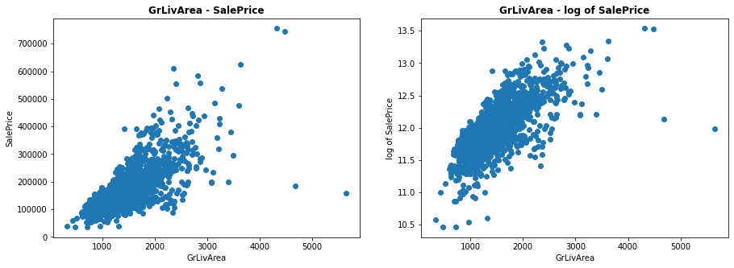

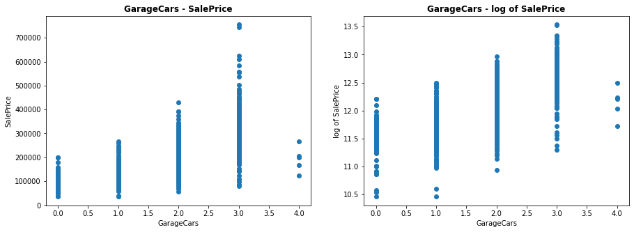

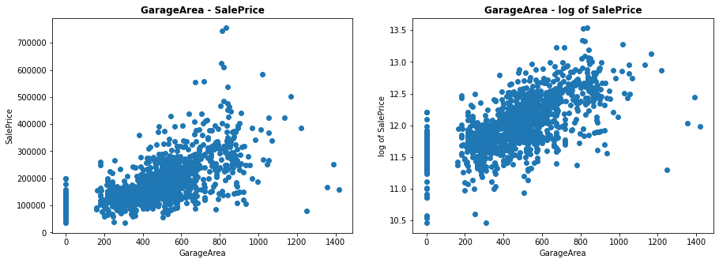

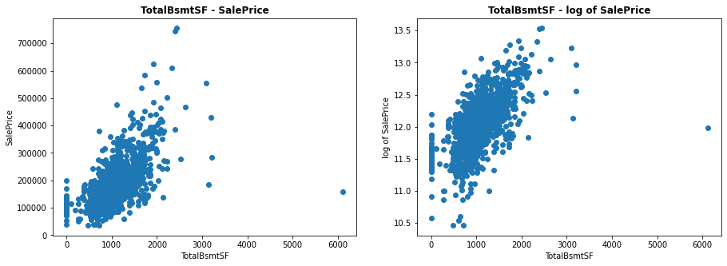

```python
#0.6::
for attr in numChosenAttributes:
    x1 = inData[attr]
    y1 = inData["SalePrice"]
    x2 = logGoalData[attr]
    y2 = logGoalData["SalePrice"]
    mplot.figure(figsize=(15,5))
    mplot.subplot(1, 2, 1)
    mplot.scatter(x1, y1)
    mplot.title("%s - SalePrice" % attr,fontweight = "bold")
    mplot.xlabel("%s" % attr)
    mplot.ylabel("SalePrice")
    mplot.subplot(1, 2, 2)
    mplot.scatter(x2, y2)
    mplot.title("%s - log of SalePrice" % attr,fontweight = "bold")
    mplot.xlabel("%s" % attr)
    mplot.ylabel("log of SalePrice")
    mplot.show()
```

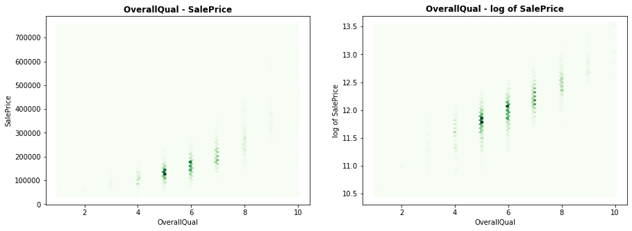

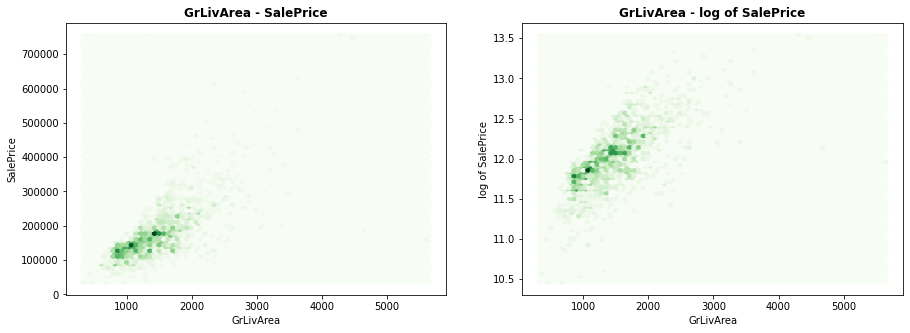

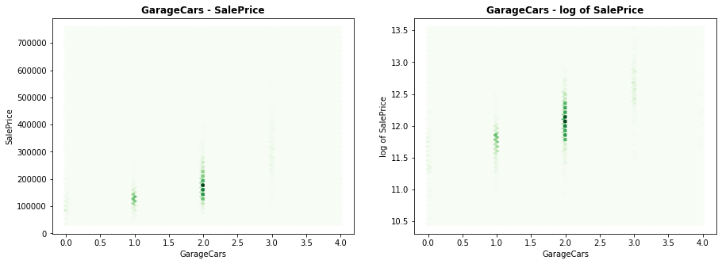

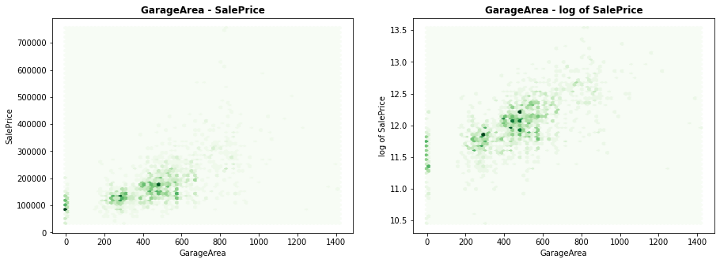

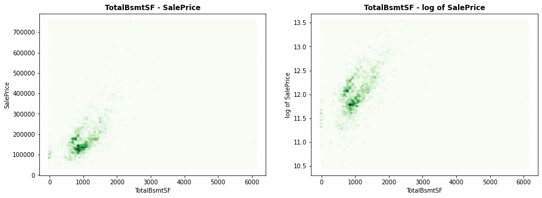

```python
for attr in numChosenAttributes:
    x1 = inData[attr]
    y1 = inData["SalePrice"]
    x2 = logGoalData[attr]
    y2 = logGoalData["SalePrice"]
    mplot.figure(figsize=(15,5))
    mplot.subplot(1, 2, 1)
    mplot.hexbin(x1, y1, cmap ='Greens', gridsize = 75)
    mplot.title("%s - SalePrice" % attr,fontweight = "bold")
    mplot.xlabel("%s" % attr)
    mplot.ylabel("SalePrice")
    mplot.subplot(1, 2, 2)
    mplot.hexbin(x2, y2, cmap ='Greens', gridsize = 75)
    mplot.title("%s - log of SalePrice" % attr,fontweight = "bold")
    mplot.xlabel("%s" % attr)
    mplot.ylabel("log of SalePrice")
    mplot.show()
```

**7) سه ویژگی دسته ای که به نظرتان در پیش بینی مفید هستند را انتخاب کنید سپس با نمودار های مناسب آن ها را نمایش دهید.**  
تمام ویژگی های غیر عددی در پایین آمده اند. در حالت کلی هنگام خرید خانه محله(Neighborhood)، کیفیت محصولات خارجی آن(ExterQual)، وضعیت آشپزخانه اش(kitchenQual)، وضعیت زیرزمین و جا دار بودن آن(BsmtQual) و استخر داشتن یا نداشتن(PoolQc) می تواند روی قیمت تاثیر بسزایی داشته باشد.

```python
#0.7::
print(categorical)
```

```
['MSZoning', 'Street', 'Alley', 'LotShape', 'LandContour', 'Utilities', 'LotConfig', 'LandSlope', 'Neighborhood', 'Condition1', 'Condition2', 'BldgType', 'HouseStyle', 'RoofStyle', 'RoofMatl', 'Exterior1st', 'Exterior2nd', 'MasVnrType', 'ExterQual', 'ExterCond', 'Foundation', 'BsmtQual', 'BsmtCond',…
```

حال برای بررسی دقیق تر نمودارمیانگین قیمت خانه ها به ازای هرکدام از مقادیر ویژگی ها را رسم می کنیم. اما چرا این نمودار؟ زیرا ما به دنبال ویژگی هستیم که خانه ها را ازنظر قیمت بیشتر متمایز کند. بنابراین ویژگی می خواهیم که مقادیر متفاوتش در رنج قیمت های کاملاً گوناگونی خانه ها را قرار دهند. یعنی ویژگی می خواهیم که میانگین قیمت خانه ها به ازای هر مقدارش تفاوت زیادی داشته باشند. دوباره هم براساس خود مقدار هدف و هم براساس لگاریتم هدف نمودارها را میکشیم.

```python
categoricalDf = inData[categorical]
```

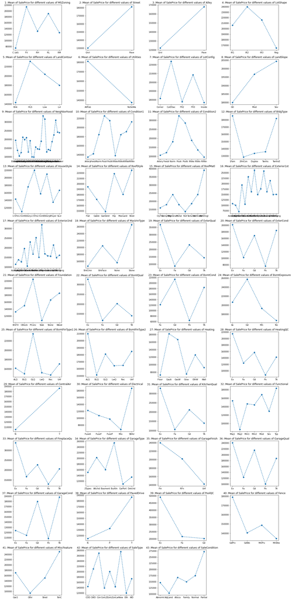

```python
i = 0
fig = mplot.figure()
for obj in categoricalDf:
    i += 1
    newFrame = inData.groupby(obj, as_index=False)['SalePrice'].mean()
    x = newFrame[obj]
    y = newFrame["SalePrice"]
    ax = fig.add_subplot(11,4,i)
    fig.subplots_adjust(10,10,13,20,.5)
    ax.plot(x, y, '--o')
    mplot.title(str(i)+"::Mean of SalePrice for different values of %s" % obj)
mplot.show()
```

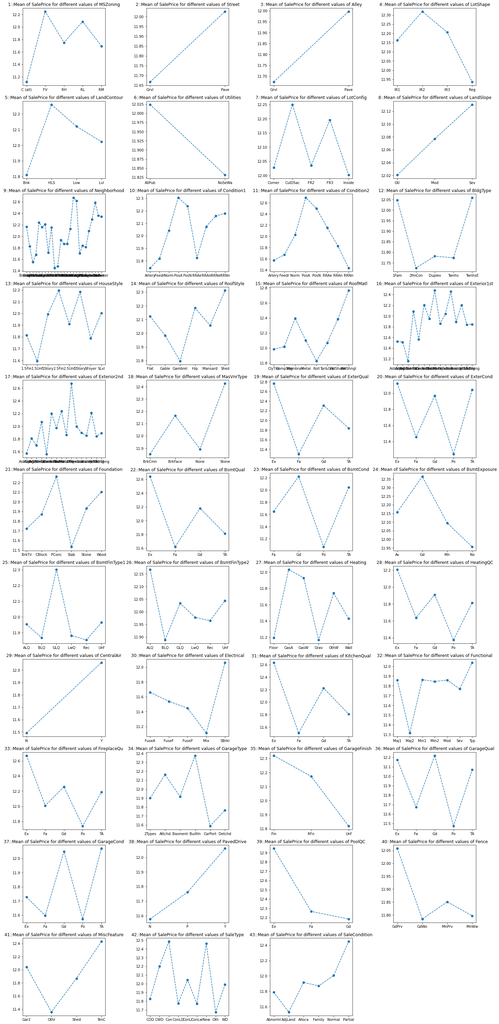

```python
i = 0
fig = mplot.figure()
for obj in categoricalDf:
    i += 1
    newFrame = logGoalData.groupby(obj, as_index=False)['SalePrice'].mean()
    x = newFrame[obj]
    y = newFrame["SalePrice"]
    ax = fig.add_subplot(11,4,i)
    fig.subplots_adjust(10,10,13,20,.5)
    ax.plot(x, y, '--o')
    mplot.title(str(i)+"::Mean of SalePrice for different values of %s" % obj)
mplot.show()
```

```python
df = dict()
for obj in categoricalDf:
    i += 1
    newFrame = inData.groupby(obj, as_index=False)['SalePrice'].mean()
    df[obj] = newFrame['SalePrice'].std()
df = panda.DataFrame.from_dict(df, orient ='index')
```

```python
df1 = dict()
for obj in categoricalDf:
    i += 1
    newFrame = logGoalData.groupby(obj, as_index=False)['SalePrice'].mean()
    df1[obj] = newFrame['SalePrice'].std()
df1 = panda.DataFrame.from_dict(df1, orient ='index')
```

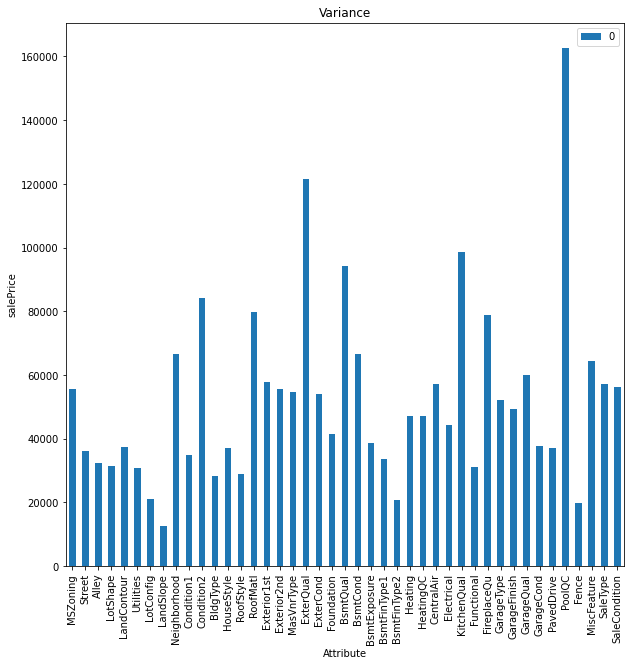

```python
df.plot(xlabel ="Attribute" ,ylabel = "salePrice" , title = "Variance",kind = 'bar', figsize=(10, 10))
```

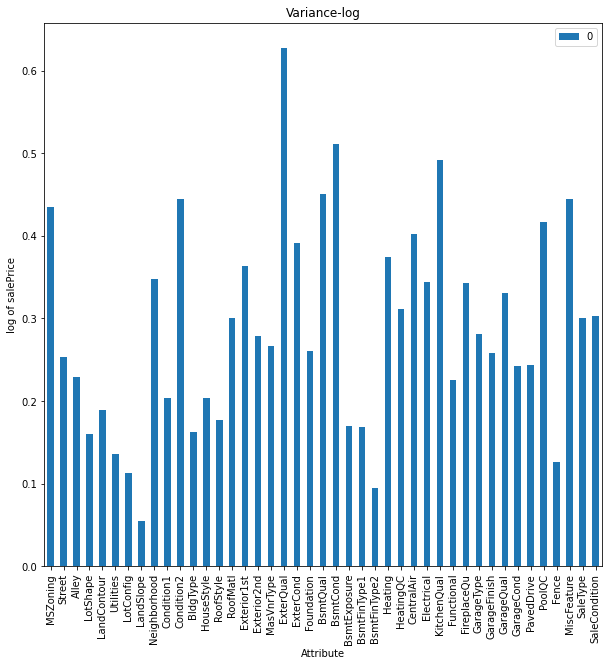

```python
df1.plot(xlabel ="Attribute" ,ylabel = "log of salePrice" ,title = "Variance-log",kind = 'bar', figsize=(10, 10))
```

```python
catChosenAttributes = ["ExterQual", "BsmtCond", "KitchenQual", "PoolQC", "MiscFeature", "Condition2"]
```

در نهایت ویژگی های غیرعددی بالا به عنوان ویژگی های غیر عددی که تاثیر زیادی بر متغیر هدف دارند انتخاب شدند. این متغیرها ترکیبی از متغیرها با واریانس بالا در دو نمودار بالاتر هستند. البته اگر نمودار میانگین های مربوط به ExterQual و KitchenQual را بببینیم متوجه شباهت این دو می شویم بدین معنی که شاید این دو روی هدف تاثیر متفاوتی ندارند و تاثیرشان به یک شکل است؛ بنابراین چند ویژگی دیگر هم در نظر میگیریم. بنابراین در کل ویژگی های زیر به عنوان ویژگی هایی که بیشترین تاثیر را بر هدف دارند انتخاب شدند.

```python
highRelation = numChosenAttributes + catChosenAttributes
highRelation
```

```
['OverallQual',
 'GrLivArea',
 'GarageCars',
 'GarageArea',
 'TotalBsmtSF',
 'ExterQual',
 'BsmtCond',
 'KitchenQual',
 'PoolQC',
 'MiscFeature',
 'Condition2']
```

```python
#Phase 1 - Preprocessing
```

## فاز اول: Preprocessing

در این فاز بایستی داده ها به خوبی پردازش شوند، چرا که در فاز های بعدی مدل ها با توجه به این داده ها آموزش میبینند و اگر داده ها به درستی پردازش نشوند میتوانند باعث گمراهی شوند در نتیجه آن مدل به درستی آموزش نبیند و قادر به تخمین درست متغیر هدف نخواهد بود. در اصل بایستی اطلاعاتی که جمع آوری شده اند را آماده فرستادن به مدل بکنیم.

**1) دور روش برای برطرف کردن مشکل داده های گمشده، 1- حذف کل ستون و 2- پرکردن مقادیر گمشده با آماره ها هستند. دیگر روش های موجود برای هندل کردن داده های گمشده را در صورت وجود مختصراً توضیح دهید و این روش ها را مقایسه کنید.**  
عملیات پر کردن خانه های خالی باید انجام شود زیرا در مراحل بعد میخواهیم این مشخصه ها را تحلیل کنیم اگر بعضی از داده ها خالی باشند تحلیل به درستی انجام نمیشود. راههای متعدد دیگری برای مدیریت داده های گم شده است ازجمله : پاک کردن آن ردیف ها، پیش بینی مقدار آن داده و ... حال پاک کردن ردیف و جایگزینی با میانگین مقایسه میکنیم:  
- پاک کردن ردیف شامل داده گم شده  
در این روش ستونی که یک یا چند داده گم شده دارد را پاک میکنیم و میتوانیم ستونها وویژگیهایی که برای بیش از نصف داده ها گم شدند را پاک کنیم.  
مزیت این روش آن است که دیتا ست حاصل مقاوم است بدین معنا که روابط و درجه ارتباط و تاثیر ویژگی ها تا حد خوبی حفظ می شود.  
ایراد این روش آن است که داده از دست میدهیم. داده های که در پیش بینی هدف می توانستند به ما کمک کنند. و اگر حجم داده های گم شده در مقایسه با داده های موجود بیشتر باشد در عمل دیتاست باقی مانده دیگر مناسب برای پیش بینی و کار نیست.  
- جایگزینی مقدار خالی با آماره ها مانند میانگین ستون  
مزیت این روش آن است که داده از دست نمیدهیم و پیاده سازی آن ساده است.  
ایراد این روش این است که تنها برای ویژگی های عددی پاسخگو است. همچنین ممکن است data leakage رخ دهد که در یادگیری ماشین بدین معناست که در اثر جایگزینی با میانگین در بعضی از ویژگی ها دیتاستی تولید کنیم که به طور غیرواقع بینانه خوشبینانه باشد و میزان ارتباط و تاثیر آن را بر ویژگی هدف بالا ببرد.  
- جایگزینی با مقدار پرتکرار  
این روش اغلب برای داده های غیر عددی کاربرد دارد. بدین شکل که سطر خالی را با مقدار پر تکرار داده ها پر میکنیم. این روش از دست رفتن داده جلوگیری میکند.  
- پیش بینی مقدار های گم شده به کمک مدل هایی مانند k تا از نزدیک ترین همسایه ها  
این روش میاییم مواردی در داده ها که از نظر کلی شرایط بسیار مشابهی با داده ما دارند را پیدا میکنیم سپس با توجه به ستون متناظر با آنها داده های گم شده را هندل می کنیم. این روش دقیق تر از روش های قبل عمل می کند و دقیق تر است. اما پیاده سازیش به نسبت سخت تر و باز هم تنها نماینده ای از مقدار صحیح را نمایش می دهد و دقیق آن را تولید نمی کند.  
- جایگیزینی با کمک کتابخانه های deep learning  
کتابخانه ای در زبان پایتون در اختیار داریم که با کمک روش های deep learning داده های از دست رفته را پر میکنند مانند کتابخانه datawig. این روش ساده و تا حد خوبی دقیق است. اما برای داده هاذ با حجم بالا بسیار کند و زمانبر خواهد بود.

**2) کدام ویژگی ها بیشترین میزان داده ی گمشده را دارند؟ آیا باید ویژگی ها با درصد بالای داده ی گمشده را از مجموعه داده حذف کرد؟ با روش های مناسب داده ها را هندل کنید.**  
در پایین ویژگی ها برحسب درصد داده های از دست رفته مرتب شده اند. البته دقت شود داده هایی که برایشان NA تعریف شده بو درصد داده های از دست رفته برایشان صفر در نظر گرفته شده است.

```python
#1.2
missingValuesPercent.sort_values("Percentage of missing values",ascending=False).head(7)
```

|  | Feature | Percentage of missing values |
| --- | --- | --- |
| 3 | LotFrontage | 17.739726 |
| 59 | GarageYrBlt | 5.547945 |
| 25 | MasVnrType | 0.547945 |
| 26 | MasVnrArea | 0.547945 |
| 42 | Electrical | 0.068493 |
| 53 | KitchenQual | 0.000000 |
| 58 | GarageType | 0.000000 |

اگر میزان داده های گمشده بسیار بالا باشد مثلاً بالای 60، 70 درصد اطلاعات دقیقی نداریم که براساسشان داده های از دست رفته را جایگزین کنیم و جایگزینی با خطای زیادی همراه خواهد بود. بنابراین تصمیم منطقی آن است که ویژگی ها را حذف کنیم اما در داده های ما بالاترین درصد گمشدگی 18 درصد است بنابراین ویژگی را حذف نمیکنیم و سعی می کنیم با روش مناسب داده ها را پر کنیم.

توابع زیر جهت هندل کردن داده های گمشده پیاده سازی میکنیم:  
1) برای پر کردن داده هایی که NA برایشان تعریف شده دسته ای جدید به نام NotHave ایجاد کردیم و این دسته را جای داده های ازدست رفته گذاشتیم.  
2) ستون های عددی بودند که مربوط به همان ستون های بالا بودند. و NA برایشان به معنای موجود نبودن آن ویژگی است اینها را هم -1 قرار دادیم.  
3) سه روش هم پیاده سازی کردیم که ستون های خالی را با آماره های مختلف یعنی میانگین، میانه و مد پر میکنیم. مد برای ویژگی های غیر عددی کاربرد دارد.

```python
#Functions
#1.1::
def fillDefinedOne(dataFrame, columns):
    for col in columns:
        dataFrame[col].fillna("NotHave", inplace = True)
def fillRelatedOne(dataFrame, columns):
    for col in columns:
        dataFrame[col].fillna(-1, inplace = True)
def fillWithMean(dataFrame, columns):#Just Num
    for col in columns:
        dataFrame[col].fillna(dataFrame[col].mean(), inplace = True)
def fillWithMod(dataFrame, columns):#Num and Object
    for col in columns:
        dataFrame[col].fillna(str(dataFrame[col].mode()), inplace = True)
def fillWithMedian(dataFrame, columns):
    for col in columns:
        dataFrame[col].fillna(dataFrame[col].median(), inplace = True)
```

در پایین نتیجه پر شدن داده های گمشده را میبینیم.

```python
fillDefinedOne(inData, definedNaCols)
inData["Alley"].isna().sum()
```

```
0
```

```python
fillRelatedOne(inData, relatedToDefined)
inData["GarageYrBlt"].isna().sum()
```

```
0
```

```python
fillWithMod(inData, categorical)
inData["MasVnrType"].isna().sum()
```

```
0
```

```python
fillWithMedian(inData, numerical)
inData["LotFrontage"].isna().sum()
```

```
0
```

**3) در ویژگی های عددی Normalizing و Standardizing داده های عددی به چه منظور انجام می شود؟ به نظر شما آیا نیاز است که داده ها خود را در این پروژه نرمالیزه کنیم؟**  
نرمالیزه کردن داده ها مقادیر آنها را در بازه ی صفر و یک قرار می دهد. استاندارد سازی آنها مقادیرشان را به گونه ای تغییر می دهد که میانگینشان صفر و انحراف از معیارشان یک شود. نرمالیزه زمانی مناسب است که گستردگی داده هایتان گاوسی نباشد و محدوده ی داده هایتان با هم متفاوت باشد مخصوصاً در روش knn مناسب است. اما استانداردسازی زمانی مناسب است که داده ها گستردگی گاوسی داشته باشند و با ایجاد شرایط جدید از نظر میانگین و انحراف معیار بتوانیم از ویژگی های این گستردگی استفاده کنیم. در linear regression هم کاربردی است. تاثیر این دو را بر نتیجه در فاز های بعد بررسی میکنیم.

```python
#1.3::
def standardize(dataFrame, column):
    mean = dataFrame[column].mean()
    std = dataFrame[column].std(axis = 0, skipna = True)
    dataFrame[column] = (dataFrame[column] - mean) / std
    return dataFrame
def normalize(dataFrame, column):
    minimum = dataFrame[column].min()
    maximum = dataFrame[column].max()
    a = maximum - minimum
    dataFrame[column] = (dataFrame[column] - minimum) / (a)
    return dataFrame
```

**4) برای اینکه مدل ما بتواند با داده های دسته ای کار کند چه روش هایی وجود دارد؟ آیا همه داده های دسته ای را باید با یک روش هندل کنیم؟**  
داده های دسته ای را مدل ها نمیتوانند پردازش کنند. بنابراین نیاز داریم به گونه ای این داده ها را به داده های عددی تبدیل کنیم. به اصطلاح به این روش ها، روش های encoding گویند. برای همه داده های دسته ای نمی توان روش یکسانی را استفاده کرد. بسته به نوع داده غیر عددی روش متفاوتی را استفاده می کنیم.  
1) داده های باینری:  
داده هایی که دو مقدار می توانند داشته باشند. این داده ها متناظر با هر دسته مقادیرشان با صفر و یک جایگزین می شود.  
2) داده های غیر ترتیبی:  
این داده ها مقادیرشان ترتیب و درجه خاصی ندارد. این داده ها با روش one hot encoding هندل می شوند. این روش به تمام مقادیر ممکن شانس یکسانی می دهد و برای هر مقدار یک ستون تولید می کند و ستون متناظر با مقدار را یک و ستون مقادیر دیگر را صفر می گذارد.  
3) داده های ترتیبی:  
این داده ها مقادیرشان درجه و ترتیب خاصی دارند مثلاً خوب، متوسط، بد. برای این داده دیکشنری هایی را تعریف می کنیم که متناظر با هر درجه از کیفیت مقدار عددی را جایگزین کنیمو این دیکشنری ها در ادامه تعریف شده اند و بعد با استفاده از replace جایگزینی انجام شده.

```python
binary = ["Street","CentralAir"]
nominal = ["MSZoning","Alley","Utilities","LotConfig"
           ,"Neighborhood","Condition1","Condition2","BldgType",
           "HouseStyle","RoofStyle","RoofMatl","Exterior1st",
           "Exterior2nd","MasVnrType","Foundation","Heating","Electrical",
           "GarageType","MiscFeature","SaleType","SaleCondition",
           "LandContour"]
ordinal = ["LotShape","LandSlope","ExterQual","ExterCond","BsmtQual",
          "BsmtCond","BsmtExposure","BsmtFinType1","BsmtFinType2",
          "HeatingQC","KitchenQual","Functional","FireplaceQu",
          "GarageFinish","GarageQual","GarageCond","PavedDrive",
          "PoolQC","Fence"]
```

```python
lotShapeDict = {'IR3':0,'IR2':1,'IR1':2,'Reg':3}
landSlopeDict = {'Sev':0,'Mod':1,'Gtl':2}
bsmtExpDict = {'NotHave':0,'No':1,'Mn':2,'Av':3,'Gd':4}
bsmtFinDict = {'NotHave':0,'Unf':1,'LwQ':2,'Rec':3,'BLQ':4,'ALQ':5,
               'GLQ':6}
funcDict = {'Sal':0,'Sev':1,'Maj2':2,'Maj1':3,'Mod':4,'Min2':5,'Min1':6
            ,'Typ':7}
garageFinDict = {'NotHave':0,'Unf':1,'RFn':2,'Fin':3}
fenceDict = {'NotHave':0,'MnWw':1,'GdWo':2,'MnPrv':3,'GdPrv':4}
pavedDict = {'N':0,'P':1,'Y':2}
definedNaDict = {'NotHave':0,'Po':2,'Fa':4,'TA':6,'Gd':8,'Ex':10}
validDict = {'Po':0,'Fa':2,'TA':4,'Gd':6,'Ex':8}
```

```python
#1.4::
def ordEncoding(dataFrame, column, tempDict):
    dataFrame[column].replace(tempDict, inplace=True)
    return dataFrame
def oneHotEncoding(dataFrame, column):
    result = dataFrame[:]
    y = panda.get_dummies(dataFrame[column], prefix=column)
    result = dataFrame.drop([column],axis = 1, inplace = False)
    result = panda.DataFrame(panda.concat([result, y], axis=1))
    return result
```

```python
#1.4::
inData["Street"] = inData["Street"].replace({'Pave':1,'Grvl':0})
inData["CentralAir"] = inData["CentralAir"].replace({'Y':1,'N':0})
for feature in ordinal:
    if feature == "LotShape":
        tempDict = lotShapeDict
    elif feature == "LandSlope":
        tempDict = landSlopeDict
    elif feature == "BsmtExposure":
        tempDict = bsmtExpDict
    elif feature == "BsmtFinType1" or feature == "BsmtFinType2":
        tempDict = bsmtFinDict
    elif feature == "Functional":
        tempDict = funcDict
    elif feature == "GarageFinish":
        tempDict = garageFinDict
    elif feature == "Fence":
        tempDict = fenceDict
    elif feature == "PavedDrive":
        tempDict = pavedDict
    elif feature in definedNaCols:
        tempDict = definedNaDict
    else:
        tempDict = validDict
    ordEncoding(inData, feature, tempDict)
# for feature in nominal:
#     inData = oneHotEncoding(inData, feature)
```

```python
for feature in nominal:
    inData = oneHotEncoding(inData, feature)
```

نتیجه ی encoding داده های دسته ای را در پایین میبینید.

```python
inData.head()
```

|  | Id | MSSubClass | LotFrontage | LotArea | Street | LotShape | LandSlope | OverallQual | OverallCond | YearBuilt | ... | SaleCondition_Abnorml | SaleCondition_AdjLand | SaleCondition_Alloca | SaleCondition_Family | SaleCondition_Normal | SaleCondition_Partial | LandContour_Bnk | LandContour_HLS | LandContour_Low | LandContour_Lvl |
| --- | --- | --- | --- | --- | --- | --- | --- | --- | --- | --- | --- | --- | --- | --- | --- | --- | --- | --- | --- | --- | --- |
| 0 | 1 | 60 | 65.0 | 8450 | 1 | 3 | 2 | 7 | 5 | 2003 | ... | 0 | 0 | 0 | 0 | 1 | 0 | 0 | 0 | 0 | 1 |
| 1 | 2 | 20 | 80.0 | 9600 | 1 | 3 | 2 | 6 | 8 | 1976 | ... | 0 | 0 | 0 | 0 | 1 | 0 | 0 | 0 | 0 | 1 |
| 2 | 3 | 60 | 68.0 | 11250 | 1 | 2 | 2 | 7 | 5 | 2001 | ... | 0 | 0 | 0 | 0 | 1 | 0 | 0 | 0 | 0 | 1 |
| 3 | 4 | 70 | 60.0 | 9550 | 1 | 2 | 2 | 7 | 5 | 1915 | ... | 1 | 0 | 0 | 0 | 0 | 0 | 0 | 0 | 0 | 1 |
| 4 | 5 | 60 | 84.0 | 14260 | 1 | 2 | 2 | 8 | 5 | 2000 | ... | 0 | 0 | 0 | 0 | 1 | 0 | 0 | 0 | 0 | 1 |

5 rows × 228 columns

تابع زیر جهت استخراج ستون های غیر عددی که با روش one hot encoding به چند ستون تبدیل شده اند؛ پیاده سازی شده است.

```python
def getSepColumns(dataFrame, same):
    result = [col for col in inData.columns if same in col]
    return result
```

**5) کدام ستون ها را می توانیم حذف کنیم؟ چرا؟**  
ستون هایی که تاثیر زیادی روی متغیر هدف ندارند را می توان حذف کرد. این ستون ها با کمک heatmap و بررسی های فاز قبل به راحتی شناسایی می شوند. همچنین ستون هایی که برای داده های زیادی مقدار یکسان دارند هم می توان حذف کرد که عملاً همان بررسی میانگین و واریانس است که در فاز قبل بررسی شده است. این داده ها در تخمین کمکی نمیکنند و تنها دقت مدل را کم میکنند و فرآیند آموزش مدل را طولانی تر و نادقیق تر می کنند.

```python
#1.5
def omitColumns(dataFrame, selected):
    allSelected = []
    for col in selected:
        allSelected.extend(getSepColumns(dataFrame, col))
    allSelected.append("SalePrice")
    columns = dataFrame.columns.to_list()
    mustDelete = [item for item in columns if item not in allSelected]
    newDataFrame = dataFrame.drop(mustDelete, axis = 1, inplace = False)
    return newDataFrame
```

**6) داده ها باید به دو دسته train و test تقسیم شوند. روی مقدار مناسب P بحث کنید. آیا روش دیگری وجود دارد؟ نام ببرید. آیا نیاز است تقسیم داده ها به صورت تصادفی باشد؟ چرا؟**  
P باید به گونه ای باشد که مقدار مناسبی داده جهت آموزش مدلمان در اختیار باشد و همچنین تا حد خوبی هم بتوانیم مدل را با داده های تست ارزیابی کنیم. اگر P مقدار بالایی داشته باشد می تواند باعث این شود که داده های زیادی جهت آموزش استفاده شود و درنتیجه مدل آموزش بسیار دقیقی از این داده ها بگیرد و به کوچکترین جزییات آن دقت کند که باعث overfitting می شود. به طور معمول به صورت 70 تا 80 درصد داده ها جهت آموزش و بقیه داده ها جهت تست به کار میروند. البته برای مدل هایمان P های مختلف تست شده اند و P انتخاب شده مناسب ترین حالت بود. در کل این درصد باید با توجه به پروژه و داده ها انتخاب شود و هزینه های محاسباتی آموزش و هزینه های تست است.  
روش های دیگر عبارتند از:  
Cross Validation: این روش بدین گونه است که داده را به K دسته تقسیم می کند و هر بار k-1 دسته به جهت آموزش و دسته باقی مانده جهت تست استفاده می شود و این فرآیند به صورت چرخشی ادامه می یابد.  
leave one out cross validation: که نوع خاصی از cross validation است.  
تقسیم داده ها به صورت تصادفی در بعضی داده ها بسیار مهم است برای مثال زمانهایی که داده ها براساس متغیر هدف یا یکی از ویژگی ها به طرز خاصی ترتیب خاصی دارند و انتخاب تصادفی باعث ایجاد اطمینان از لحاظ گستردگی مناسب داده ها می شود و آموزش مدل جهت گیری خاصی ندارد. اگر داده ها گستردگی مناسبی داشتند پیاده سازی با انتخاب تصادفی لزومی ندارد اما مشکلی هم ایجاد نمیکند. اینجا جداسازی داده ها به صورت تصادفی انجام شده تا از گستردگی اطمینان حاصل شود.

```python
#1.6
def getRandToSplit(dataFrame, p):
    num.random.seed(8)
    randSeq = num.random.rand(len(dataFrame))
    randSeq = randSeq < p * 0.01
    return randSeq
```

## فاز دوم: Model Training, Evaluation and Hyperparameter Tuning

در این فاز از روی داده هایی که در مرحله قبل پردازش کردیم و اصلاح کردیم، داده های تست و آموزش را استخراج می کنیم. سپس می خواهیم سه مدل پیاده سازی کنیم که با کمک داده های آموزشی تعریف شده آموزش ببینند و نتیجه آموزششان با تخمین مجموعه تست و مقایسه با جواب صحیح تست سنجیده شود. در ادامه پیاده سازی و مقایسه حالات مختلف داده مربوط به هر مدل را می بینیم. صورت این فاز از 4 گام و سوال تشکیل شده که موارد 1، 2، 4 برای هر مدل جداگانه بررسی شده.

```python
#Phase 2 - Model Training, Evaluation and Hyperparameter Tuning
```

در قدم اول داده های تست و آموزش را آماده میکنیم. این کار با کمک تابع تقسیم رندوم که در فاز قبل پیاده سازی شده است، انجام میپذیرد. سپس در هر مجموعه داده ویژگی ها از هدف را جدا میکنیم. ویژگی های آموزش و متغیر هدف ورودی های مدل جهت آموزش، ویژگی های تست و متغیر هدف تست جهت تست مدل پیاده سازی شده است.

```python
def getTestTrain(dataFrame, p):
    seq = getRandToSplit(dataFrame, p)
    toTrain = dataFrame[seq]
    toTest = dataFrame[~seq]
    trainAttr = toTrain.loc[:, dataFrame.columns != "SalePrice"]
    trainTarget = toTrain.loc[:, dataFrame.columns == "SalePrice"]
    testAttr = toTest.loc[:, dataFrame.columns != "SalePrice"]
    testTarget = toTest.loc[:, dataFrame.columns == "SalePrice"]
    return testAttr, testTarget, trainAttr, trainTarget
```

```python
def getReadyToModel(dataFrame, wanted, p):
    newDf = omitColumns(dataFrame, wanted)
    testAttr, testTarget, trainAttr, trainTarget = getTestTrain(newDf, p)
    return testAttr, testTarget, trainAttr, trainTarget
```

مدل هایی که جهت تخمین استفاده می کنیم از کتابخانه scikit-Learn گرفته شده است. نکته مهم این است که؛ از آنجا که متغیر هدف به شکل کلاس نیستند و به شکل اعداد پیوسته اند نباید از classifier ها استفاده کنیم، بلکه بایستی از regressor ها استفاده کنییم. همچنین دو تابع سنجش خطای mae و rmse هم از این کتابخانه برای سنجش مدل به کار میروند.

```python
#Libraries
# from sklearn.neighbors import KNeighborsClassifier
from sklearn.neighbors import KNeighborsRegressor
from sklearn.metrics import mean_absolute_error
from sklearn.metrics import mean_squared_error
from sklearn.tree import DecisionTreeRegressor
from sklearn.linear_model import LinearRegression
import math
```

```python
import warnings;
warnings.simplefilter('ignore')
```

### فراخوانی مدل ها و توابع خطا

در مرحله اول یک نمونه از کلاس هر مدل می سازیم. روی داده آموزشی fit می کنیم. با کمک مدل آموزش شده نتایج تست را تخمین میزنیم. برای سنجش میزان صحت مدل ها، با کمک توابع mae و rmse میزان خطای تخمین ها نسبت به مقدار صحیح هدف برای داده های تست می سنجیم.

```python
#Functions
#K-Nearest-Neighbors
def KNN(testAttr, testTarget, trainAttr, trainTarget, neighborCnt):
    knn = KNeighborsRegressor(n_neighbors=neighborCnt)
    knn.fit(trainAttr, trainTarget)
    return knn.predict(testAttr)
#Decision Tree
def dtree(testAttr, testTarget, trainAttr, trainTarget, maxDep):
    dt = DecisionTreeRegressor(max_depth= maxDep)
    dt.fit(trainAttr, trainTarget)
    return dt.predict(testAttr)
#Linear Regression
def linReg(testAttr, testTarget, trainAttr, trainTarget):
    lr = LinearRegression()
    lr.fit(trainAttr, trainTarget)
    return lr.predict(testAttr)
#MAE
def mae(result, actual):
    return mean_absolute_error(result, actual)
#RMSE
def rmse(result, actual):
    return math.sqrt(mean_squared_error(result, actual))
```

### حالات مختلف پیش پردازش

```python
inData.drop("Id", axis = 1, inplace = True)
inData.drop("YrSold", axis = 1, inplace = True)
inData.drop("MoSold", axis = 1, inplace = True)
```

```python
allData = inData[:]
```

```python
droppedNa = readData("train.csv")
droppedNa.dropna(inplace=True, axis=1)
```

```python
droppedNaJustNum = droppedNa.copy()
droppedNaJustNum = omitColumns(droppedNaJustNum, numerical)
```

```python
justNumData = inData[:]
justNumData = omitColumns(justNumData, numerical)
```

```python
highRelData = inData[:]
highRelData = omitColumns(highRelData, highRelation)
```

```python
def normalizeDf(df):
    normalizedData = df.copy()
    for col in normalizedData:
        if col in numerical and col != "SalePrice":
            normalizedData = normalize(normalizedData, col)
    return normalizedData
```

```python
def standardizeDf(df):
    standardizedData = df.copy()
    for col in standardizedData:
        if col in numerical and col != "SalePrice":
            standardizedData = standardize(standardizedData, col)
    return standardizedData
```

### مدل KNN

برای سنجش نقش هایپرپارامتر تعداد همسایه های در بررسی شده داخل یک حلقه خطا ها سنجیده می شوند و در قالب یک دیتافریم نگه داری میشوند. یک دیتافریم خطاها متناظر با تعداد همسایه ها یکبار برای تست و یکبار برای داده ی آموزش. این کار کمک می کند هم از نظر چشمی مقایسه حالات مختلف راحت تر باشد و هم راحت تر نموداری مناسب برای این حالات رسم می کنیم.

```python
#KNN
def evalKnn(testAttr, testTarget, trainAttr, trainTarget, nc):
    count = []
    maeKnnTest = []
    maeKnnTrain = []
    rmseKnnTest = []
    rmseKnnTrain = []
    for neighborCnt in range(1, nc):
        count.append(neighborCnt)
        knnTest = KNN(testAttr, testTarget, trainAttr, trainTarget, neighborCnt)
        knnTrain = KNN(trainAttr, trainTarget, trainAttr, trainTarget, neighborCnt)
        testKnnRes = panda.DataFrame(knnTest, columns=["SalePrice"])
        trainKnnRes = panda.DataFrame(knnTrain, columns=["SalePrice"])
        maeKnnTest.append(mae(testKnnRes, testTarget))
        maeKnnTrain.append(mae(trainKnnRes, trainTarget))
        rmseKnnTest.append(rmse(testKnnRes, testTarget))
        rmseKnnTrain.append(rmse(trainKnnRes, trainTarget))
    knnTestDf = panda.DataFrame(list(zip(count, maeKnnTest, rmseKnnTest)), columns=['neighborCount', 'MAE For Test Data', 'RMSE For Test Data'])
    knnTrainDf = panda.DataFrame(list(zip(count, maeKnnTrain, rmseKnnTrain)), columns=['neighborCount', 'MAE For Train Data', 'RMSE For Train Data'])
    return knnTestDf, knnTrainDf
```

### تست حالات مختلف داده در الگوریتم KNN

حال حالات مختلف داده را با کمک مدل KNN ارزیابی میکنیم و برای ده همسایه دیتافریم حاصل را هم نشان می دهیم. سپس برای بهترین حالت تاثیر هایپرپارامتر و نمودار حاصل را نشان می دهیم.

#### پاک کردن ستون ها با داده های از دست رفته و تنها ویژگی های عددی

```python
##TESTING DIFFERENT CASES
testAttr, testTarget, trainAttr, trainTarget = getTestTrain(droppedNaJustNum, 75)
testdf, traindf = evalKnn(testAttr, testTarget, trainAttr, trainTarget, 10)
```

```python
testdf
```

|  | neighborCount | MAE For Test Data | RMSE For Test Data |
| --- | --- | --- | --- |
| 0 | 1 | 33630.407407 | 56715.400721 |
| 1 | 2 | 30705.256410 | 49900.269006 |
| 2 | 3 | 28768.956315 | 48902.534807 |
| 3 | 4 | 27435.233618 | 48033.990138 |
| 4 | 5 | 28240.036467 | 48850.183273 |
| 5 | 6 | 28407.133428 | 49122.464974 |
| 6 | 7 | 28767.212861 | 49691.001678 |
| 7 | 8 | 28635.524573 | 49709.245122 |
| 8 | 9 | 28639.413105 | 49545.336298 |

```python
traindf
```

|  | neighborCount | MAE For Train Data | RMSE For Train Data |
| --- | --- | --- | --- |
| 0 | 1 | 13.659152 | 323.117568 |
| 1 | 2 | 18685.071235 | 29189.084964 |
| 2 | 3 | 21923.737000 | 34532.342751 |
| 3 | 4 | 23675.775924 | 36789.545892 |
| 4 | 5 | 24631.876285 | 38351.325453 |
| 5 | 6 | 25175.121581 | 39275.415478 |
| 6 | 7 | 25528.285714 | 40077.169971 |
| 7 | 8 | 26154.638188 | 41042.807600 |
| 8 | 9 | 26550.170624 | 41419.033110 |

#### تنها ویژگی های عددی

```python
testAttr, testTarget, trainAttr, trainTarget = getTestTrain(justNumData, 75)
testdf, traindf = evalKnn(testAttr, testTarget, trainAttr, trainTarget, 10)
```

```python
testdf
```

|  | neighborCount | MAE For Test Data | RMSE For Test Data |
| --- | --- | --- | --- |
| 0 | 1 | 31618.521368 | 54297.825996 |
| 1 | 2 | 29986.364672 | 48609.911767 |
| 2 | 3 | 28144.521368 | 47885.520710 |
| 3 | 4 | 27654.710826 | 47230.158431 |
| 4 | 5 | 27742.064957 | 48035.121374 |
| 5 | 6 | 28230.002374 | 48417.165719 |
| 6 | 7 | 28590.029711 | 49307.212027 |
| 7 | 8 | 28446.363960 | 49415.075618 |
| 8 | 9 | 28584.811016 | 49733.087737 |

```python
traindf
```

|  | neighborCount | MAE For Train Data | RMSE For Train Data |
| --- | --- | --- | --- |
| 0 | 1 | 13.659152 | 323.117568 |
| 1 | 2 | 18371.298016 | 28997.488262 |
| 2 | 3 | 21735.608055 | 34066.055754 |
| 3 | 4 | 23096.564923 | 36102.881681 |
| 4 | 5 | 24425.501353 | 38244.742597 |
| 5 | 6 | 25233.444845 | 39529.389703 |
| 6 | 7 | 25695.342393 | 40482.414523 |
| 7 | 8 | 26118.016794 | 41077.463274 |
| 8 | 9 | 26674.954313 | 41533.628457 |

#### تمام داده ها و پر شده با میانه و مد و استفاده از encoding های گفته شده در بالاتر

```python
testAttr, testTarget, trainAttr, trainTarget = getTestTrain(allData, 75)
testdf, traindf = evalKnn(testAttr, testTarget, trainAttr, trainTarget, 10)
```

```python
testdf
```

|  | neighborCount | MAE For Test Data | RMSE For Test Data |
| --- | --- | --- | --- |
| 0 | 1 | 31638.031339 | 54299.056273 |
| 1 | 2 | 29969.413105 | 48608.438375 |
| 2 | 3 | 28128.092118 | 47887.354802 |
| 3 | 4 | 27659.340456 | 47231.426583 |
| 4 | 5 | 27732.093447 | 48034.720728 |
| 5 | 6 | 28233.254036 | 48418.878519 |
| 6 | 7 | 28590.620676 | 49309.545160 |
| 7 | 8 | 28446.363960 | 49415.075618 |
| 8 | 9 | 28584.811016 | 49733.087737 |

```python
traindf
```

|  | neighborCount | MAE For Train Data | RMSE For Train Data |
| --- | --- | --- | --- |
| 0 | 1 | 0.000000 | 0.000000 |
| 1 | 2 | 18379.389991 | 28999.754998 |
| 2 | 3 | 21733.474001 | 34065.931509 |
| 3 | 4 | 23080.255185 | 36082.775505 |
| 4 | 5 | 24426.853922 | 38244.968727 |
| 5 | 6 | 25234.398858 | 39530.190925 |
| 6 | 7 | 25697.106660 | 40483.571008 |
| 7 | 8 | 26117.751691 | 41077.803163 |
| 8 | 9 | 26674.954313 | 41533.628457 |

#### ویژگی هایی که ارتباط بالایی با ستون هدف دارند

```python
testAttr, testTarget, trainAttr, trainTarget = getTestTrain(highRelData, 75)
testdf, traindf = evalKnn(testAttr, testTarget, trainAttr, trainTarget, 10)
```

```python
testdf
```

|  | neighborCount | MAE For Test Data | RMSE For Test Data |
| --- | --- | --- | --- |
| 0 | 1 | 29958.817664 | 45381.916218 |
| 1 | 2 | 27818.454416 | 44510.193917 |
| 2 | 3 | 26745.245014 | 41896.651006 |
| 3 | 4 | 26403.668091 | 40733.533453 |
| 4 | 5 | 25612.622792 | 39698.859775 |
| 5 | 6 | 25941.948243 | 39532.695666 |
| 6 | 7 | 26267.450956 | 40525.703801 |
| 7 | 8 | 26006.436254 | 39910.996675 |
| 8 | 9 | 25935.532130 | 39577.587024 |

```python
traindf
```

|  | neighborCount | MAE For Train Data | RMSE For Train Data |
| --- | --- | --- | --- |
| 0 | 1 | 172.662759 | 1519.613516 |
| 1 | 2 | 17531.095582 | 28595.259290 |
| 2 | 3 | 21056.943192 | 33800.413441 |
| 3 | 4 | 22149.212353 | 35418.580303 |
| 4 | 5 | 22811.363751 | 36837.170971 |
| 5 | 6 | 23314.464232 | 37311.429763 |
| 6 | 7 | 23899.916012 | 37858.499664 |
| 7 | 8 | 24136.080365 | 37992.968923 |
| 8 | 9 | 24590.534115 | 39078.310002 |

#### نرمال شده ویژگی هایی که با هدف رابطه زیادی دارند

```python
normCheck = normalizeDf(highRelData)
testAttr, testTarget, trainAttr, trainTarget = getTestTrain(normCheck, 75)
testdf, traindf = evalKnn(testAttr, testTarget, trainAttr, trainTarget, 10)
```

```python
testdf
```

|  | neighborCount | MAE For Test Data | RMSE For Test Data |
| --- | --- | --- | --- |
| 0 | 1 | 26677.085470 | 39158.302798 |
| 1 | 2 | 24537.485755 | 36001.868000 |
| 2 | 3 | 24047.651472 | 34207.697893 |
| 3 | 4 | 22907.712251 | 33669.742122 |
| 4 | 5 | 22534.515100 | 34156.971417 |
| 5 | 6 | 21978.400760 | 32914.877325 |
| 6 | 7 | 21519.922670 | 31703.885558 |
| 7 | 8 | 21510.116097 | 31760.869835 |
| 8 | 9 | 21256.221906 | 31592.229818 |

```python
traindf
```

|  | neighborCount | MAE For Train Data | RMSE For Train Data |
| --- | --- | --- | --- |
| 0 | 1 | 188.442741 | 1609.927718 |
| 1 | 2 | 14730.040577 | 24038.260564 |
| 2 | 3 | 17554.331229 | 28522.322456 |
| 3 | 4 | 18883.011046 | 30517.227935 |
| 4 | 5 | 19386.128404 | 31916.983218 |
| 5 | 6 | 20215.622483 | 32956.026188 |
| 6 | 7 | 20442.042381 | 33241.476993 |
| 7 | 8 | 21075.809851 | 34137.119402 |
| 8 | 9 | 21492.722172 | 34785.178260 |

#### آزمون و خطا بر روی ستون هایی که بیشترین رابطه را با هدف دارند

```python
checkHighRelData = inData.copy()
checkHighRelData = omitColumns(checkHighRelData, [
    'OverallQual',
 'GrLivArea',
#  'GarageCars',
 'GarageArea',
 'TotalBsmtSF',
 'ExterQual',
 'BsmtCond',
 'KitchenQual',
#  'PoolQC'
 'MiscFeature',
 'Condition2'
])
checkHighRelData
# checkHighRelData
```

|  | OverallQual | ExterQual | BsmtCond | TotalBsmtSF | GrLivArea | KitchenQual | GarageArea | SalePrice | Condition2_Artery | Condition2_Feedr | ... | Condition2_PosA | Condition2_PosN | Condition2_RRAe | Condition2_RRAn | Condition2_RRNn | MiscFeature_Gar2 | MiscFeature_NotHave | MiscFeature_Othr | MiscFeature_Shed | MiscFeature_TenC |
| --- | --- | --- | --- | --- | --- | --- | --- | --- | --- | --- | --- | --- | --- | --- | --- | --- | --- | --- | --- | --- | --- |
| 0 | 7 | 6 | 6 | 856 | 1710 | 6 | 548 | 208500 | 0 | 0 | ... | 0 | 0 | 0 | 0 | 0 | 0 | 1 | 0 | 0 | 0 |
| 1 | 6 | 4 | 6 | 1262 | 1262 | 4 | 460 | 181500 | 0 | 0 | ... | 0 | 0 | 0 | 0 | 0 | 0 | 1 | 0 | 0 | 0 |
| 2 | 7 | 6 | 6 | 920 | 1786 | 6 | 608 | 223500 | 0 | 0 | ... | 0 | 0 | 0 | 0 | 0 | 0 | 1 | 0 | 0 | 0 |
| 3 | 7 | 4 | 8 | 756 | 1717 | 6 | 642 | 140000 | 0 | 0 | ... | 0 | 0 | 0 | 0 | 0 | 0 | 1 | 0 | 0 | 0 |
| 4 | 8 | 6 | 6 | 1145 | 2198 | 6 | 836 | 250000 | 0 | 0 | ... | 0 | 0 | 0 | 0 | 0 | 0 | 1 | 0 | 0 | 0 |
| ... | ... | ... | ... | ... | ... | ... | ... | ... | ... | ... | ... | ... | ... | ... | ... | ... | ... | ... | ... | ... | ... |
| 1455 | 6 | 4 | 6 | 953 | 1647 | 4 | 460 | 175000 | 0 | 0 | ... | 0 | 0 | 0 | 0 | 0 | 0 | 1 | 0 | 0 | 0 |
| 1456 | 6 | 4 | 6 | 1542 | 2073 | 4 | 500 | 210000 | 0 | 0 | ... | 0 | 0 | 0 | 0 | 0 | 0 | 1 | 0 | 0 | 0 |
| 1457 | 7 | 8 | 8 | 1152 | 2340 | 6 | 252 | 266500 | 0 | 0 | ... | 0 | 0 | 0 | 0 | 0 | 0 | 0 | 0 | 1 | 0 |
| 1458 | 5 | 4 | 6 | 1078 | 1078 | 6 | 240 | 142125 | 0 | 0 | ... | 0 | 0 | 0 | 0 | 0 | 0 | 1 | 0 | 0 | 0 |
| 1459 | 5 | 6 | 6 | 1256 | 1256 | 4 | 276 | 147500 | 0 | 0 | ... | 0 | 0 | 0 | 0 | 0 | 0 | 1 | 0 | 0 | 0 |

1460 rows × 21 columns

```python
testAttr, testTarget, trainAttr, trainTarget = getTestTrain(checkHighRelData, 75)
testdf, traindf = evalKnn(testAttr, testTarget, trainAttr, trainTarget, 10)
```

```python
testdf
```

|  | neighborCount | MAE For Test Data | RMSE For Test Data |
| --- | --- | --- | --- |
| 0 | 1 | 29958.817664 | 45381.916218 |
| 1 | 2 | 27818.454416 | 44510.193917 |
| 2 | 3 | 26745.245014 | 41896.651006 |
| 3 | 4 | 26403.668091 | 40733.533453 |
| 4 | 5 | 25612.622792 | 39698.859775 |
| 5 | 6 | 25950.495252 | 39543.594298 |
| 6 | 7 | 26267.450956 | 40525.703801 |
| 7 | 8 | 26006.436254 | 39910.996675 |
| 8 | 9 | 25935.532130 | 39577.587024 |

```python
traindf
```

|  | neighborCount | MAE For Train Data | RMSE For Train Data |
| --- | --- | --- | --- |
| 0 | 1 | 173.474301 | 1519.853817 |
| 1 | 2 | 17531.095582 | 28595.259290 |
| 2 | 3 | 21057.484220 | 33800.642601 |
| 3 | 4 | 22149.415239 | 35418.723866 |
| 4 | 5 | 22811.363751 | 36837.170971 |
| 5 | 6 | 23314.599489 | 37311.510029 |
| 6 | 7 | 23899.916012 | 37858.499664 |
| 7 | 8 | 24136.080365 | 37992.968923 |
| 8 | 9 | 24590.534115 | 39078.310002 |

#### نرمال شده داده هایی که بهترین نتیجه را دارند

```python
normCheck = normalizeDf(checkHighRelData)
testAttr, testTarget, trainAttr, trainTarget = getTestTrain(normCheck, 75)
testdf, traindf = evalKnn(testAttr, testTarget, trainAttr, trainTarget, 10)
```

```python
testdf
```

|  | neighborCount | MAE For Test Data | RMSE For Test Data |
| --- | --- | --- | --- |
| 0 | 1 | 26183.689459 | 38618.650448 |
| 1 | 2 | 24494.438746 | 35492.055013 |
| 2 | 3 | 23057.051282 | 33038.292286 |
| 3 | 4 | 22009.762108 | 32552.742085 |
| 4 | 5 | 21595.119658 | 32355.918305 |
| 5 | 6 | 21126.888414 | 31407.334339 |
| 6 | 7 | 20644.335775 | 30486.059987 |
| 7 | 8 | 20673.178063 | 30842.063398 |
| 8 | 9 | 20547.341564 | 30783.942848 |

```python
traindf
```

|  | neighborCount | MAE For Train Data | RMSE For Train Data |
| --- | --- | --- | --- |
| 0 | 1 | 182.040577 | 1565.172919 |
| 1 | 2 | 14546.954914 | 22174.016246 |
| 2 | 3 | 17187.801623 | 26496.321582 |
| 3 | 4 | 18811.726781 | 29407.801289 |
| 4 | 5 | 19410.759423 | 31095.604453 |
| 5 | 6 | 20031.170123 | 31939.113111 |
| 6 | 7 | 20307.803684 | 32780.324618 |
| 7 | 8 | 20861.739292 | 33777.241230 |
| 8 | 9 | 21296.470795 | 34479.198296 |

#### استاندارد شده داده هایی که بهترین نتیجه را دارند

```python
standardCheck = standardizeDf(checkHighRelData)
testAttr, testTarget, trainAttr, trainTarget = getTestTrain(standardCheck, 75)
testdf, traindf = evalKnn(testAttr, testTarget, trainAttr, trainTarget, 10)
```

```python
testdf
```

|  | neighborCount | MAE For Test Data | RMSE For Test Data |
| --- | --- | --- | --- |
| 0 | 1 | 25194.398860 | 37564.261307 |
| 1 | 2 | 23324.965812 | 35562.288747 |
| 2 | 3 | 21758.049383 | 32332.990854 |
| 3 | 4 | 21173.266382 | 31975.707251 |
| 4 | 5 | 20554.900855 | 30491.384793 |
| 5 | 6 | 20114.772555 | 30452.086560 |
| 6 | 7 | 20046.503053 | 30211.083750 |
| 7 | 8 | 19859.897436 | 29735.106812 |
| 8 | 9 | 19892.743273 | 29566.747554 |

```python
traindf
```

|  | neighborCount | MAE For Train Data | RMSE For Train Data |
| --- | --- | --- | --- |
| 0 | 1 | 189.254283 | 1610.154541 |
| 1 | 2 | 14063.001353 | 22095.043139 |
| 2 | 3 | 16537.498647 | 26655.879941 |
| 3 | 4 | 17944.857078 | 29057.384641 |
| 4 | 5 | 18680.763931 | 30481.833597 |
| 5 | 6 | 19491.182898 | 32019.097697 |
| 6 | 7 | 19981.561123 | 32507.617817 |
| 7 | 8 | 20213.356740 | 33046.706413 |
| 8 | 9 | 20288.309688 | 33030.743120 |

### بررسی هایپرپارامتر تعداد همسایه ها در داده هایی که بهترین نتیجه را دارند

```python
testdf, traindf = evalKnn(testAttr, testTarget, trainAttr, trainTarget, 100)
```

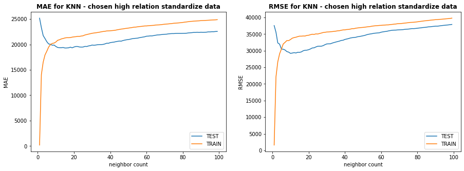

```python
mplot.figure(figsize=(15,5))
x = testdf["neighborCount"]
y = testdf["MAE For Test Data"]
mplot.subplot(1,2,1)
mplot.plot(x, y, '-')
x1 = traindf["neighborCount"]
y1 = traindf["MAE For Train Data"]
mplot.plot(x1, y1, '-')
mplot.legend(["TEST", "TRAIN"])
mplot.title("MAE for KNN - chosen high relation standardize data",fontweight = "bold")
mplot.xlabel("neighbor count")
mplot.ylabel("MAE")
mplot.subplot(1,2,2)
x = testdf["neighborCount"]
y = testdf["RMSE For Test Data"]
mplot.plot(x, y, '-')
x1 = traindf["neighborCount"]
y1 = traindf["RMSE For Train Data"]
mplot.plot(x1, y1, '-')
mplot.legend(["TEST", "TRAIN"])
mplot.title("RMSE for KNN - chosen high relation standardize data",fontweight = "bold")
mplot.xlabel("neighbor count")
mplot.ylabel("RMSE")
```

### بررسی مدل KNN

همانطور که در نتایج بالا میبنیم نتایج برای داده های نرمال شده و استاندارد شده ویژگی هایی که از بین ویژگی ها با آزمون و خطا انتخاب شده اند بهترین نتیجه را دارند. آن ویژگی های حذف، وِیژگی هایی بودند که به ازای سطر های زیادی نتایج یکسان داشتند و روی آموزش مدل تاثیر چشم گیری نداشتند. همچنین در مدل هایی که براساس فاصله هستند مانند KNN نرمال سازی داده ها از اهمیت بالایی برخوردار است. چون باعث می شود تمام مقادیر در بازه ی صفر یک تاثیرشان را بهتر نشان دهند. این مورد در تصاویر پایین مشخص ترند. زمانی که یک داده بازه ی بزرگی دارد بقیه بازه های کوچک داده های خاصی در یک ناحیه متمرکز می شوند که شناسایی نزدیک ترین کار سختی است، امّا با نرمال شدن همه در بازه ای یکسان قرار می گیرند و شناسایی آسان تر خواهد بود.

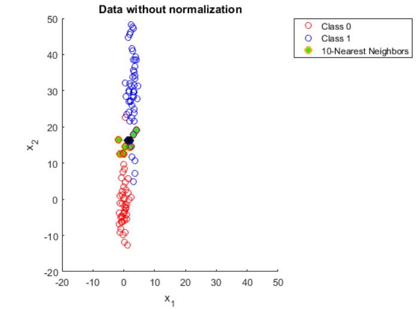

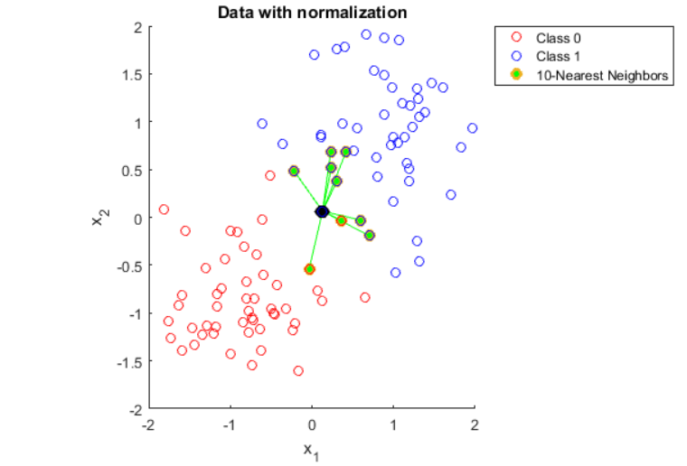

هایپر پارامتر تعداد همسایه ها باید به گونه ای انتخاب شود که به اندازه ای کوچک نباشد که خطا های کوچکی مثلاً ازدحام داده ها در یک نقطه خاص باعث انتخاب کلاس اشتباه نشود و به اندازه ای بزرگ نباشد که یک کلاس به کلاس دیگری غلبه کند و تخمین را جهت دار کند. بهترین راه یافتن مقدار مناسب آزمون و خطاست که بالا انجام شده است. نمودار این مورد در بالا مشاهده می شود.

### تست حالات مختلف داده در الگوریتم Decision Tree

حال حالات مختلف داده را با کمک مدل Decision Tree ارزیابی میکنیم و برای حداکثر عمق ده تا پانزده دیتافریم حاصل را هم نشان می دهیم. سپس برای بهترین حالت تاثیر هایپرپارامتر و نمودار حاصل را نشان می دهیم.

```python
def evalDT(testAttr, testTarget, trainAttr, trainTarget, dc):
    depth = []
    maeDtTest = []
    maeDtTrain = []
    rmseDtTest = []
    rmseDtTrain = []
    for dep in range(1, dc):
        depth.append(dep)
        dtTest = dtree(testAttr, testTarget, trainAttr, trainTarget, dep)
        dtTrain = dtree(trainAttr, trainTarget, trainAttr, trainTarget, dep)
        testDtRes = panda.DataFrame(dtTest, columns=["SalePrice"])
        trainDtRes = panda.DataFrame(dtTrain, columns=["SalePrice"])
        maeDtTest.append(mae(testDtRes, testTarget))
        maeDtTrain.append(mae(trainDtRes, trainTarget))
        rmseDtTest.append(rmse(testDtRes, testTarget))
        rmseDtTrain.append(rmse(trainDtRes, trainTarget))
    dtTestDf = panda.DataFrame(list(zip(depth, maeDtTest, rmseDtTest)), columns=['treeDepth', 'MAE For Test Data', 'RMSE For Test Data'])
    dtTrainDf = panda.DataFrame(list(zip(depth, maeDtTrain, rmseDtTrain)), columns=['treeDepth', 'MAE For Train Data', 'RMSE For Train Data'])
    return dtTestDf, dtTrainDf
```

#### پاک کردن ستون ها با داده های از دست رفته و تنها ویژگی های عددی

```python
##TESTING DIFFERENT CASES
testAttr, testTarget, trainAttr, trainTarget = getTestTrain(droppedNaJustNum, 75)
testdf, traindf = evalDT(testAttr, testTarget, trainAttr, trainTarget, 10)
```

```python
testdf
```

|  | treeDepth | MAE For Test Data | RMSE For Test Data |
| --- | --- | --- | --- |
| 0 | 1 | 40585.360821 | 54823.032088 |
| 1 | 2 | 30557.227567 | 44180.542122 |
| 2 | 3 | 27354.162405 | 35966.446351 |
| 3 | 4 | 23976.192281 | 31968.615887 |
| 4 | 5 | 24198.018843 | 32305.225935 |
| 5 | 6 | 23651.874636 | 35212.963343 |
| 6 | 7 | 22815.843552 | 34890.487477 |
| 7 | 8 | 22734.645670 | 35383.401778 |
| 8 | 9 | 23040.026195 | 38405.223699 |

```python
traindf
```

|  | treeDepth | MAE For Train Data | RMSE For Train Data |
| --- | --- | --- | --- |
| 0 | 1 | 44122.246226 | 59872.402843 |
| 1 | 2 | 35584.151900 | 49251.013895 |
| 2 | 3 | 30318.329705 | 41471.572466 |
| 3 | 4 | 25536.898873 | 35585.004988 |
| 4 | 5 | 22012.958572 | 30524.278969 |
| 5 | 6 | 17943.616693 | 24832.714521 |
| 6 | 7 | 14651.143703 | 20194.695481 |
| 7 | 8 | 11452.945333 | 16140.486142 |
| 8 | 9 | 8346.615610 | 12180.587052 |

#### تنها ویژگی های عددی

```python
testAttr, testTarget, trainAttr, trainTarget = getTestTrain(justNumData, 75)
testdf, traindf = evalDT(testAttr, testTarget, trainAttr, trainTarget, 10)
```

```python
testdf
```

|  | treeDepth | MAE For Test Data | RMSE For Test Data |
| --- | --- | --- | --- |
| 0 | 1 | 40585.360821 | 54823.032088 |
| 1 | 2 | 30557.227567 | 44180.542122 |
| 2 | 3 | 27354.162405 | 35966.446351 |
| 3 | 4 | 24789.506331 | 33731.247242 |
| 4 | 5 | 24970.330381 | 33953.997113 |
| 5 | 6 | 23171.070959 | 33235.016988 |
| 6 | 7 | 22112.585009 | 31664.149547 |
| 7 | 8 | 22660.753913 | 33613.838490 |
| 8 | 9 | 21696.033602 | 31866.520190 |

```python
traindf
```

|  | treeDepth | MAE For Train Data | RMSE For Train Data |
| --- | --- | --- | --- |
| 0 | 1 | 44122.246226 | 59872.402843 |
| 1 | 2 | 35584.151900 | 49251.013895 |
| 2 | 3 | 30318.329705 | 41471.572466 |
| 3 | 4 | 25489.996896 | 35365.196359 |
| 4 | 5 | 21870.332572 | 29992.769148 |
| 5 | 6 | 17925.274716 | 24497.101016 |
| 6 | 7 | 14574.638810 | 19734.797017 |
| 7 | 8 | 11116.385454 | 15843.488884 |
| 8 | 9 | 8172.419523 | 12078.860083 |

#### تمام داده ها و پر شده با میانه و مد و استفاده از encoding های گفته شده در بالاتر

```python
testAttr, testTarget, trainAttr, trainTarget = getTestTrain(allData, 75)
testdf, traindf = evalDT(testAttr, testTarget, trainAttr, trainTarget, 10)
```

```python
testdf
```

|  | treeDepth | MAE For Test Data | RMSE For Test Data |
| --- | --- | --- | --- |
| 0 | 1 | 40585.360821 | 54823.032088 |
| 1 | 2 | 30557.227567 | 44180.542122 |
| 2 | 3 | 27354.162405 | 35966.446351 |
| 3 | 4 | 24789.506331 | 33731.247242 |
| 4 | 5 | 24667.143623 | 34020.069846 |
| 5 | 6 | 22663.779407 | 32565.724741 |
| 6 | 7 | 21172.604155 | 30538.889341 |
| 7 | 8 | 21177.915247 | 32154.701842 |
| 8 | 9 | 21024.783104 | 31307.228383 |

```python
traindf
```

|  | treeDepth | MAE For Train Data | RMSE For Train Data |
| --- | --- | --- | --- |
| 0 | 1 | 44122.246226 | 59872.402843 |
| 1 | 2 | 35584.151900 | 49251.013895 |
| 2 | 3 | 30318.329705 | 41471.572466 |
| 3 | 4 | 25489.996896 | 35365.196359 |
| 4 | 5 | 21833.127452 | 29904.707756 |
| 5 | 6 | 17695.371849 | 24104.173214 |
| 6 | 7 | 14144.921060 | 19488.643415 |
| 7 | 8 | 11032.351122 | 15743.479697 |
| 8 | 9 | 8115.849273 | 12021.035766 |

#### ویژگی هایی که ارتباط بالایی با ستون هدف دارند

```python
testAttr, testTarget, trainAttr, trainTarget = getTestTrain(highRelData, 75)
testdf, traindf = evalDT(testAttr, testTarget, trainAttr, trainTarget, 10)
```

```python
testdf
```

|  | treeDepth | MAE For Test Data | RMSE For Test Data |
| --- | --- | --- | --- |
| 0 | 1 | 40585.360821 | 54823.032088 |
| 1 | 2 | 30557.227567 | 44180.542122 |
| 2 | 3 | 28246.865898 | 41068.803085 |
| 3 | 4 | 25002.045208 | 37224.460639 |
| 4 | 5 | 24283.864864 | 34914.389357 |
| 5 | 6 | 24709.749967 | 43655.756650 |
| 6 | 7 | 24435.810064 | 35231.702495 |
| 7 | 8 | 25045.656556 | 36821.220367 |
| 8 | 9 | 25830.937443 | 37892.304001 |

```python
traindf
```

|  | treeDepth | MAE For Train Data | RMSE For Train Data |
| --- | --- | --- | --- |
| 0 | 1 | 44122.246226 | 59872.402843 |
| 1 | 2 | 35584.151900 | 49251.013895 |
| 2 | 3 | 30455.538702 | 42069.944752 |
| 3 | 4 | 25918.264787 | 36443.359956 |
| 4 | 5 | 22296.478859 | 31616.087306 |
| 5 | 6 | 18939.934064 | 26982.285383 |
| 6 | 7 | 16257.097629 | 22692.624783 |
| 7 | 8 | 13131.225686 | 18575.967153 |
| 8 | 9 | 10444.694173 | 15468.332891 |

#### آزمون و خطا بر روی ستون هایی که بیشترین رابطه را با هدف دارند

```python
checkHighRelData = inData[:]
checkHighRelData = omitColumns(checkHighRelData, [
    'OverallQual',
 'GrLivArea',
#  'GarageCars',
 'GarageArea',
 'TotalBsmtSF',
 'ExterQual',
 'BsmtCond',
 'KitchenQual',
#  'PoolQC'
 'MiscFeature'
 'Condition2'
])
checkHighRelData
```

|  | OverallQual | ExterQual | BsmtCond | TotalBsmtSF | GrLivArea | KitchenQual | GarageArea | SalePrice |
| --- | --- | --- | --- | --- | --- | --- | --- | --- |
| 0 | 7 | 6 | 6 | 856 | 1710 | 6 | 548 | 208500 |
| 1 | 6 | 4 | 6 | 1262 | 1262 | 4 | 460 | 181500 |
| 2 | 7 | 6 | 6 | 920 | 1786 | 6 | 608 | 223500 |
| 3 | 7 | 4 | 8 | 756 | 1717 | 6 | 642 | 140000 |
| 4 | 8 | 6 | 6 | 1145 | 2198 | 6 | 836 | 250000 |
| ... | ... | ... | ... | ... | ... | ... | ... | ... |
| 1455 | 6 | 4 | 6 | 953 | 1647 | 4 | 460 | 175000 |
| 1456 | 6 | 4 | 6 | 1542 | 2073 | 4 | 500 | 210000 |
| 1457 | 7 | 8 | 8 | 1152 | 2340 | 6 | 252 | 266500 |
| 1458 | 5 | 4 | 6 | 1078 | 1078 | 6 | 240 | 142125 |
| 1459 | 5 | 6 | 6 | 1256 | 1256 | 4 | 276 | 147500 |

1460 rows × 8 columns

```python
testAttr, testTarget, trainAttr, trainTarget = getTestTrain(checkHighRelData, 75)
testdf, traindf = evalDT(testAttr, testTarget, trainAttr, trainTarget, 10)
```

```python
testdf
```

|  | treeDepth | MAE For Test Data | RMSE For Test Data |
| --- | --- | --- | --- |
| 0 | 1 | 40585.360821 | 54823.032088 |
| 1 | 2 | 30557.227567 | 44180.542122 |
| 2 | 3 | 27367.546292 | 38668.007763 |
| 3 | 4 | 24739.814146 | 35402.273173 |
| 4 | 5 | 24941.786718 | 33703.902856 |
| 5 | 6 | 24181.845598 | 33488.426440 |
| 6 | 7 | 23656.261606 | 33328.118610 |
| 7 | 8 | 23675.120419 | 33790.167138 |
| 8 | 9 | 25354.337410 | 36873.674951 |

```python
traindf
```

|  | treeDepth | MAE For Train Data | RMSE For Train Data |
| --- | --- | --- | --- |
| 0 | 1 | 44122.246226 | 59872.402843 |
| 1 | 2 | 35584.151900 | 49251.013895 |
| 2 | 3 | 30399.442228 | 42400.919279 |
| 3 | 4 | 25880.258047 | 36334.706904 |
| 4 | 5 | 21848.622952 | 30305.057830 |
| 5 | 6 | 18395.064098 | 25286.459701 |
| 6 | 7 | 15813.492646 | 21676.430401 |
| 7 | 8 | 12836.270211 | 18121.424234 |
| 8 | 9 | 10445.620105 | 15296.587763 |

#### نرمال شده داده هایی که بهترین نتیجه را دارند

```python
normCheck = normalizeDf(checkHighRelData)
testAttr, testTarget, trainAttr, trainTarget = getTestTrain(normCheck, 75)
testdf, traindf = evalDT(testAttr, testTarget, trainAttr, trainTarget, 10)
```

```python
testdf
```

|  | treeDepth | MAE For Test Data | RMSE For Test Data |
| --- | --- | --- | --- |
| 0 | 1 | 40585.360821 | 54823.032088 |
| 1 | 2 | 30557.227567 | 44180.542122 |
| 2 | 3 | 27367.546292 | 38668.007763 |
| 3 | 4 | 24739.814146 | 35402.273173 |
| 4 | 5 | 24941.786718 | 33703.902856 |
| 5 | 6 | 24181.845598 | 33488.426440 |
| 6 | 7 | 23656.261606 | 33328.118610 |
| 7 | 8 | 23675.120419 | 33790.167138 |
| 8 | 9 | 25354.337410 | 36873.674951 |

```python
traindf
```

|  | treeDepth | MAE For Train Data | RMSE For Train Data |
| --- | --- | --- | --- |
| 0 | 1 | 44122.246226 | 59872.402843 |
| 1 | 2 | 35584.151900 | 49251.013895 |
| 2 | 3 | 30399.442228 | 42400.919279 |
| 3 | 4 | 25880.258047 | 36334.706904 |
| 4 | 5 | 21848.622952 | 30305.057830 |
| 5 | 6 | 18395.064098 | 25286.459701 |
| 6 | 7 | 15813.492646 | 21676.430401 |
| 7 | 8 | 12836.270211 | 18121.424234 |
| 8 | 9 | 10445.620105 | 15296.587763 |

#### استاندارد شده داده هایی که بهترین نتیجه را دارند

```python
standardCheck = standardizeDf(checkHighRelData)
testAttr, testTarget, trainAttr, trainTarget = getTestTrain(standardCheck, 75)
testdf, traindf = evalDT(testAttr, testTarget, trainAttr, trainTarget, 15)
```

```python
testdf
```

|  | treeDepth | MAE For Test Data | RMSE For Test Data |
| --- | --- | --- | --- |
| 0 | 1 | 40585.360821 | 54823.032088 |
| 1 | 2 | 30557.227567 | 44180.542122 |
| 2 | 3 | 27367.546292 | 38668.007763 |
| 3 | 4 | 24739.814146 | 35402.273173 |
| 4 | 5 | 24941.786718 | 33703.902856 |
| 5 | 6 | 24181.845598 | 33488.426440 |
| 6 | 7 | 23656.261606 | 33328.118610 |
| 7 | 8 | 23675.120419 | 33790.167138 |
| 8 | 9 | 25354.337410 | 36873.674951 |
| 9 | 10 | 25155.009917 | 36890.974181 |
| 10 | 11 | 26015.924313 | 38409.155389 |
| 11 | 12 | 24936.859793 | 35759.110380 |
| 12 | 13 | 25609.017150 | 35622.251510 |
| 13 | 14 | 26699.736393 | 38300.222949 |

```python
traindf
```

|  | treeDepth | MAE For Train Data | RMSE For Train Data |
| --- | --- | --- | --- |
| 0 | 1 | 44122.246226 | 59872.402843 |
| 1 | 2 | 35584.151900 | 49251.013895 |
| 2 | 3 | 30399.442228 | 42400.919279 |
| 3 | 4 | 25880.258047 | 36334.706904 |
| 4 | 5 | 21848.622952 | 30305.057830 |
| 5 | 6 | 18395.064098 | 25286.459701 |
| 6 | 7 | 15813.492646 | 21676.430401 |
| 7 | 8 | 12836.270211 | 18121.424234 |
| 8 | 9 | 10445.620105 | 15296.587763 |
| 9 | 10 | 7729.082589 | 12122.628009 |
| 10 | 11 | 5631.329714 | 9803.498052 |
| 11 | 12 | 3973.398700 | 7757.617884 |
| 12 | 13 | 2845.109405 | 6115.918213 |
| 13 | 14 | 1898.434019 | 4769.073520 |

### بررسی هایپرپارامتر حداکثر عمق در داده هایی که بهترین نتیجه را دارند

```python
normCheck = normalizeDf(checkHighRelData)
testAttr, testTarget, trainAttr, trainTarget = getTestTrain(normCheck, 75)
testdf, traindf = evalDT(testAttr, testTarget, trainAttr, trainTarget, 150)
```

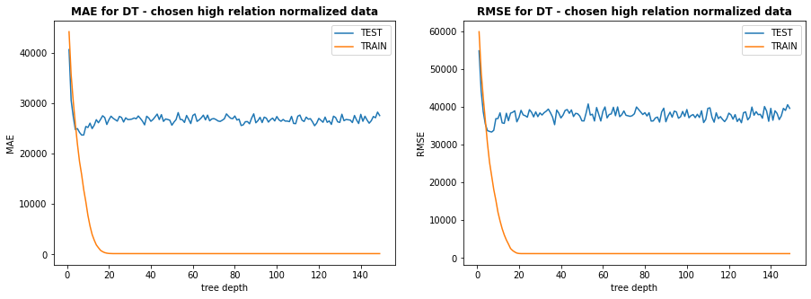

```python
mplot.figure(figsize=(15,5))
x = testdf["treeDepth"]
y = testdf["MAE For Test Data"]
mplot.subplot(1,2,1)
mplot.plot(x, y, '-')
x1 = traindf["treeDepth"]
y1 = traindf["MAE For Train Data"]
mplot.plot(x1, y1, '-')
mplot.legend(["TEST", "TRAIN"])
mplot.title("MAE for DT - chosen high relation normalized data",fontweight = "bold")
mplot.xlabel("tree depth")
mplot.ylabel("MAE")
mplot.subplot(1,2,2)
x = testdf["treeDepth"]
y = testdf["RMSE For Test Data"]
mplot.plot(x, y, '-')
x1 = traindf["treeDepth"]
y1 = traindf["RMSE For Train Data"]
mplot.plot(x1, y1, '-')
mplot.legend(["TEST", "TRAIN"])
mplot.title("RMSE for DT - chosen high relation normalized data",fontweight = "bold")
mplot.xlabel("tree depth")
mplot.ylabel("RMSE")
```

### تست حالات مختلف داده در الگوریتم Linear Regression

حال حالات مختلف داده را با کمک مدل Linear Regression ارزیابی میکنیم و دیتافریم حاصل را هم نشان می دهیم.

```python
def evalLinReg(testAttr, testTarget, trainAttr, trainTarget):
    maeLinTest = []
    maeLinTrain = []
    rmseLinTest = []
    rmseLinTrain = []
    linTest = linReg(testAttr, testTarget, trainAttr, trainTarget)
    linTrain = linReg(trainAttr, trainTarget, trainAttr, trainTarget)
    testLinRes = panda.DataFrame(linTest, columns=["SalePrice"])
    trainLinRes = panda.DataFrame(linTrain, columns=["SalePrice"])
    maeLinTest.append(mae(testLinRes, testTarget))
    maeLinTrain.append(mae(trainLinRes, trainTarget))
    rmseLinTest.append(rmse(testLinRes, testTarget))
    rmseLinTrain.append(rmse(trainLinRes, trainTarget))
    linTestDf = panda.DataFrame(list(zip(maeLinTest, rmseLinTest)), columns=['MAE For Test Data', 'RMSE For Test Data'])
    linTrainDf = panda.DataFrame(list(zip(maeLinTrain, rmseLinTrain)), columns=['MAE For Train Data', 'RMSE For Train Data'])
    return linTestDf, linTrainDf
```

#### پاک کردن ستون ها با داده های از دست رفته و تنها ویژگی های عددی

```python
##TESTING DIFFERENT CASES
testAttr, testTarget, trainAttr, trainTarget = getTestTrain(droppedNaJustNum, 75)
testdf, traindf = evalLinReg(testAttr, testTarget, trainAttr, trainTarget)
```

```python
testdf
```

|  | MAE For Test Data | RMSE For Test Data |
| --- | --- | --- |
| 0 | 20922.574179 | 32172.118525 |

```python
traindf
```

|  | MAE For Train Data | RMSE For Train Data |
| --- | --- | --- |
| 0 | 21933.38049 | 35782.542326 |

#### تنها ویژگی های عددی

```python
testAttr, testTarget, trainAttr, trainTarget = getTestTrain(justNumData, 75)
testdf, traindf = evalLinReg(testAttr, testTarget, trainAttr, trainTarget)
```

```python
testdf
```

|  | MAE For Test Data | RMSE For Test Data |
| --- | --- | --- |
| 0 | 20645.137547 | 31118.314584 |

```python
traindf
```

|  | MAE For Train Data | RMSE For Train Data |
| --- | --- | --- |
| 0 | 21784.379026 | 35178.077596 |

#### ویژگی هایی که ارتباط بالایی با ستون هدف دارند

```python
testAttr, testTarget, trainAttr, trainTarget = getTestTrain(highRelData, 75)
testdf, traindf = evalLinReg(testAttr, testTarget, trainAttr, trainTarget)
```

```python
testdf
```

|  | MAE For Test Data | RMSE For Test Data |
| --- | --- | --- |
| 0 | 22660.862811 | 32832.739668 |

```python
traindf
```

|  | MAE For Train Data | RMSE For Train Data |
| --- | --- | --- |
| 0 | 24322.160485 | 37799.399326 |

#### آزمون و خطا بر روی ستون هایی که بیشترین رابطه را با هدف دارند

```python
checkHighRelData = inData[:]
checkHighRelData = omitColumns(checkHighRelData, [
    'OverallQual',
 'GrLivArea',
#  'GarageCars',
 'GarageArea',
 'TotalBsmtSF',
#  'ExterQual',
#  'BsmtCond'
 'KitchenQual'
#  'PoolQC'
#  'MiscFeature'
#  'Condition2'
])
checkHighRelData
```

|  | OverallQual | TotalBsmtSF | GrLivArea | KitchenQual | GarageArea | SalePrice |
| --- | --- | --- | --- | --- | --- | --- |
| 0 | 7 | 856 | 1710 | 6 | 548 | 208500 |
| 1 | 6 | 1262 | 1262 | 4 | 460 | 181500 |
| 2 | 7 | 920 | 1786 | 6 | 608 | 223500 |
| 3 | 7 | 756 | 1717 | 6 | 642 | 140000 |
| 4 | 8 | 1145 | 2198 | 6 | 836 | 250000 |
| ... | ... | ... | ... | ... | ... | ... |
| 1455 | 6 | 953 | 1647 | 4 | 460 | 175000 |
| 1456 | 6 | 1542 | 2073 | 4 | 500 | 210000 |
| 1457 | 7 | 1152 | 2340 | 6 | 252 | 266500 |
| 1458 | 5 | 1078 | 1078 | 6 | 240 | 142125 |
| 1459 | 5 | 1256 | 1256 | 4 | 276 | 147500 |

1460 rows × 6 columns

```python
testAttr, testTarget, trainAttr, trainTarget = getTestTrain(checkHighRelData, 75)
testdf, traindf = evalLinReg(testAttr, testTarget, trainAttr, trainTarget)
```

```python
testdf
```

|  | MAE For Test Data | RMSE For Test Data |
| --- | --- | --- |
| 0 | 22305.858285 | 33454.637383 |

```python
traindf
```

|  | MAE For Train Data | RMSE For Train Data |
| --- | --- | --- |
| 0 | 24547.672735 | 39159.924033 |

#### تمام داده ها و پر شده با میانه و مد و استفاده از encoding های گفته شده در بالاتر

```python
testAttr, testTarget, trainAttr, trainTarget = getTestTrain(allData, 75)
testdf, traindf = evalLinReg(testAttr, testTarget, trainAttr, trainTarget)
```

```python
testdf
```

|  | MAE For Test Data | RMSE For Test Data |
| --- | --- | --- |
| 0 | 16729.012158 | 24404.541976 |

```python
traindf
```

|  | MAE For Train Data | RMSE For Train Data |
| --- | --- | --- |
| 0 | 15423.182721 | 23067.561173 |

#### نرمال شده داده هایی که بهترین نتیجه را دارند

```python
normAll = normalizeDf(allData)
```

```python
testAttr, testTarget, trainAttr, trainTarget = getTestTrain(normAll, 75)
testdf, traindf = evalLinReg(testAttr, testTarget, trainAttr, trainTarget)
```

```python
testdf
```

|  | MAE For Test Data | RMSE For Test Data |
| --- | --- | --- |
| 0 | 2.097012e+11 | 3.928750e+12 |

```python
traindf
```

|  | MAE For Train Data | RMSE For Train Data |
| --- | --- | --- |
| 0 | 15423.246619 | 23067.562823 |

#### استاندارد شده داده هایی که بهترین نتیجه را دارند

```python
standardAll = standardizeDf(allData)
```

```python
testAttr, testTarget, trainAttr, trainTarget = getTestTrain(standardAll, 75)
testdf, traindf = evalLinReg(testAttr, testTarget, trainAttr, trainTarget)
```

```python
testdf
```

|  | MAE For Test Data | RMSE For Test Data |
| --- | --- | --- |
| 0 | 16729.012158 | 24404.541976 |

```python
traindf
```

|  | MAE For Train Data | RMSE For Train Data |
| --- | --- | --- |
| 0 | 15423.182721 | 23067.561173 |

### بررسی مدل Linear Regression

همانطور که در نتایج بالا میبنیم نتایج برای تمام داده ها از همه حالات بهتر بود و خطاهای آن در بازه مطلوب قرار گرفت. همچنین حالت استاندارد تغییری زیادی نکرد اما با نرمال سازی نتایج بدتر شد. شاید یکی از دلایل این بود که با نرمال سازی مقدار زیادی داده ازدست دادیم. همچنین با نرمال سازی داده ها را بسیار بهم نزدیک میکنیم که کار پردازش را برای مدل سخت می کند.

**3) در مورد overfitting و underfitting تحقیق کنید و بررسی کنید که آیا مدل های شما underfitting یا overfitting اتفاق افتاده است؟**  
-overfitting :  
حالتی است که داده ای که آموزش روی آن انجام می شود پیچیدگی زیادی دارد و اطلاعات زیادی به مدل می دهد که باعث می شود مدل به کوچکترین حزییات(یا به اصطلاح noise) هم دقت کند و برای داده های آموزشی با خطای بسیار کمی نتایج را تولید کند اما برای داده های تست به آن خوبی جواب ندهد و با خطای زیادی نتیجه را تخمین بزند.  
-underfitting :  
حالتی است که داده های آموزشی بسیار ساده اند و به هیچ عنوان اطلاعات کافی به مدل جهت آموزش دیدن و تخمین به مدل نمی دهد. همچنین ممکن است در صورتی رخ دهد که بخواهیم یک مدل خطی را با داده های غیر خطی آموزش دهیم. در این حالت مدل به قدری ناکافی آموزش دیده است که حتی داده های آموزشی را هم با خطای بالایی تخمین می زند.  
مدل Decision Tree ابتدا دچار underfitting است چون عمق درخت کم است و مدل بسیار ساده است اما رفته رفته با افزایش عمق درخت به overfitting می رسد چرا که بسیار مدل پیچیده می شود.  
مدل KNN هم ابتدا دچارoverfitting است رفته رفته با افزایش k بهتر می شود اما جایی به بعد دچار underfitting می شود چرا که فضا صاف تر می شود و همه کلاس ها تعدادشان یکدست می شود و مفهوم مدل KNN ازبین میرود.  
با مقایسه نتایج linear regression متوجه می شویم این داده در داده های تست و آموزش نتایج بسیار نزدیکی داشتند و نه دچار overfitting و نه دچار underfitting نشده است.

## فاز سوم:Ensemble Methods

در این فاز دو روش از روش های یادگیری گروهی را بررسی خواهیم کرد.

```python
#Phase 3
```

```python
#Libariries
from sklearn.ensemble import RandomForestRegressor
```

### Random Forest

```python
def forest(testAttr, testTarget, trainAttr, trainTarget, hyperParam):
    estimatorsCnt, maxDepth = hyperParam
    forest = RandomForestRegressor(n_estimators=estimatorsCnt, max_depth=maxDepth)
    forest.fit(trainAttr, trainTarget)
    return forest.predict(testAttr)
```

```python
def evalForestEstim(testAttr, testTarget, trainAttr, trainTarget, hyperParam):
    maeForestTest = []
    maeForestTrain = []
    rmseForestTest = []
    rmseForestTrain = []
    forestTest = forest(testAttr, testTarget, trainAttr, trainTarget, hyperParam)
    forestTrain = forest(trainAttr, trainTarget, trainAttr, trainTarget, hyperParam)
    testForestRes = panda.DataFrame(forestTest, columns=["SalePrice"])
    trainForestRes = panda.DataFrame(forestTrain, columns=["SalePrice"])
    maeForestTest.append(mae(testForestRes, testTarget))
    maeForestTrain.append(mae(trainForestRes, trainTarget))
    rmseForestTest.append(rmse(testForestRes, testTarget))
    rmseForestTrain.append(rmse(trainForestRes, trainTarget))
    forestTestDf = panda.DataFrame(list(zip(maeForestTest, rmseForestTest)), columns=['MAE For Test Data', 'RMSE For Test Data'])
    forestTrainDf = panda.DataFrame(list(zip(maeForestTrain, rmseForestTrain)), columns=['MAE For Train Data', 'RMSE For Train Data'])
    return forestTestDf, forestTrainDf
```

```python
checkHighRelData = inData[:]
checkHighRelData = omitColumns(checkHighRelData, [
    'OverallQual',
 'GrLivArea',
#  'GarageCars',
 'GarageArea',
 'TotalBsmtSF',
 'ExterQual',
 'BsmtCond',
 'KitchenQual',
#  'PoolQC'
 'MiscFeature'
 'Condition2'
])
checkHighRelData
```

|  | OverallQual | ExterQual | BsmtCond | TotalBsmtSF | GrLivArea | KitchenQual | GarageArea | SalePrice |
| --- | --- | --- | --- | --- | --- | --- | --- | --- |
| 0 | 7 | 6 | 6 | 856 | 1710 | 6 | 548 | 208500 |
| 1 | 6 | 4 | 6 | 1262 | 1262 | 4 | 460 | 181500 |
| 2 | 7 | 6 | 6 | 920 | 1786 | 6 | 608 | 223500 |
| 3 | 7 | 4 | 8 | 756 | 1717 | 6 | 642 | 140000 |
| 4 | 8 | 6 | 6 | 1145 | 2198 | 6 | 836 | 250000 |
| ... | ... | ... | ... | ... | ... | ... | ... | ... |
| 1455 | 6 | 4 | 6 | 953 | 1647 | 4 | 460 | 175000 |
| 1456 | 6 | 4 | 6 | 1542 | 2073 | 4 | 500 | 210000 |
| 1457 | 7 | 8 | 8 | 1152 | 2340 | 6 | 252 | 266500 |
| 1458 | 5 | 4 | 6 | 1078 | 1078 | 6 | 240 | 142125 |
| 1459 | 5 | 6 | 6 | 1256 | 1256 | 4 | 276 | 147500 |

1460 rows × 8 columns

```python
# testAttr, testTarget, trainAttr, trainTarget = getTestTrain(checkHighRelData, 75)
# forestTestDf, forestTrainDf = evalForestEstim(testAttr, testTarget, trainAttr, trainTarget)
```

### بررسی دو هایپر پارامتر حداکثر عمق درخت و تعداد درخت های تخمین گر

```python
from sklearn.model_selection import RandomizedSearchCV
randomGrid = {'n_estimators' : [100, 150, 200, 250, 300, 350, 400, 450, 500, 550, 600, 650, 700, 750],
             'max_depth' : [10, 20, 30, 40, 50, 60, 70, 80, 90, 100]}
```

```python
testAttr, testTarget, trainAttr, trainTarget = getTestTrain(checkHighRelData, 75)
```

```python
toCheckForest = RandomForestRegressor()
forestRandom = RandomizedSearchCV(estimator=toCheckForest, param_distributions=randomGrid,
                                 n_iter=100)
forestRandom.fit(trainAttr, trainTarget)
```

```
RandomizedSearchCV(estimator=RandomForestRegressor(), n_iter=100,
                   param_distributions={'max_depth': [10, 20, 30, 40, 50, 60,
                                                      70, 80, 90, 100],
                                        'n_estimators': [100, 150, 200, 250,
                                                         300, 350, 400, 450,
                                                         500, 550, 600, 650,
                                                         700, 750]})
```

```python
forestRandom.best_params_
```

```
{'n_estimators': 100, 'max_depth': 100}
```

افزایش تعداد تخمین زن ها و همچنین عمق درخت ها هردو می تواند باعث پیچیدگی مدل و داده های آموزشی و درنتیجه overfit شدن نتیجه شوند.(که درپایین مشاهده میکنیم.) از طرفی کم کردن آنها باعث ساده شدن داده ها و underfit شدن نتیجه می شود. مدل را با هایپرپارامترهای پیشنهادی اجرا کردیم. نتیجه آموزش و خطا ها در پایین آمده است.

```python
forestTestDf, forestTrainDf = evalForestEstim(testAttr, testTarget, trainAttr, trainTarget, [100, 100])
```

```python
forestTestDf
```

|  | MAE For Test Data | RMSE For Test Data |
| --- | --- | --- |
| 0 | 20276.179295 | 29490.872254 |

```python
forestTrainDf
```

|  | MAE For Train Data | RMSE For Train Data |
| --- | --- | --- |
| 0 | 8031.317675 | 13384.220838 |

```python
from sklearn.ensemble import VotingRegressor
```

### Voting Regression

در این روش تعدادی مدل به مدل داده می شود و مدل میانگینی از خروجی های مدل های ورودی را به عنوان خروجی می دهد. بدین جهت سه مدل فاز قبل در حالت بهینه شان را ساختیم و به همرا تمام داده ها به voting regression دادیم.

```python
testAttr, testTarget, trainAttr, trainTarget = getTestTrain(allData, 75)
```

```python
toVoteKnn = KNeighborsRegressor(n_neighbors=8)
toVoteDt = DecisionTreeRegressor(max_depth=7)
toVoteLin = LinearRegression()
toVoteKnn.fit(trainAttr, trainTarget)
toVoteDt.fit(trainAttr, trainTarget)
toVoteLin.fit(trainAttr, trainTarget)
```

```
LinearRegression()
```

```python
def execVote(testAttr, testTarget, trainAttr, trainTarget):
    vote = VotingRegressor(estimators=[('knn', toVoteKnn), ('dt', toVoteDt), ('lin', toVoteLin)])
    vote.fit(trainAttr, trainTarget)
    return vote.predict(testAttr)
```

```python
def evalVote(testAttr, testTarget, trainAttr, trainTarget):
    maeVoteTest = []
    maeVoteTrain = []
    rmseVoteTest = []
    rmseVoteTrain = []
    voteTest = execVote(testAttr, testTarget, trainAttr, trainTarget)
    voteTrain = execVote(trainAttr, trainTarget, trainAttr, trainTarget)
    testVoteRes = panda.DataFrame(voteTest, columns=["SalePrice"])
    trainVoteRes = panda.DataFrame(voteTrain, columns=["SalePrice"])
    maeVoteTest.append(mae(testVoteRes, testTarget))
    maeVoteTrain.append(mae(trainVoteRes, trainTarget))
    rmseVoteTest.append(rmse(testVoteRes, testTarget))
    rmseVoteTrain.append(rmse(trainVoteRes, trainTarget))
    voteTestDf = panda.DataFrame(list(zip(maeVoteTest, rmseVoteTest)), columns=['MAE For Test Data', 'RMSE For Test Data'])
    voteTrainDf = panda.DataFrame(list(zip(maeVoteTrain, rmseVoteTrain)), columns=['MAE For Train Data', 'RMSE For Train Data'])
    return voteTestDf, voteTrainDf
#     return testVoteRes
```

```python
voteTestDf, voteTrainDf = evalVote(testAttr, testTarget, trainAttr, trainTarget)
```

```python
voteTestDf
```

|  | MAE For Test Data | RMSE For Test Data |
| --- | --- | --- |
| 0 | 15840.048174 | 26607.835073 |

```python
voteTrainDf
```

|  | MAE For Train Data | RMSE For Train Data |
| --- | --- | --- |
| 0 | 13768.774792 | 21191.391223 |

همانطور که بالاتر گفته شد روش voting regression میانگینی از مدل های مختلف می گیرد و نتیجه می دهد. این روش در حالاتی که اطلاعات کافی از داده هایمان نداریم و نمی توانیم با توجه به آن بهترین مدل را انتخاب کنیم یا وقت کافی برای تست مدل های مختلف و مقایسه نتایج آنها نداریم بسیار مناسب است چون می تواند از اکثر مدل ها نتیجه بهتری دهد.(مثلاً اینجا نتیجه از knn و درخت تصمیم بهتر بود.) اما اگر یکی از مدل ها دچار overfitting یا underfitting باشد می تواند به نتیجه مدلی که به تنهایی عملکرد مناسبی داشت تاثیر منفی بگذارد.( برای مثال نتیجه حاصل نسبت به Linear regression که در تست و آموزش نتایج نزدیک داشت دچار overfit بسیار کمی است.)

## نتیجه گیری

در مسائل یادگیری ماشین شناخت داده ها و اصلاح آنها از اهمیت بالایی برخوردار است. شناخت کافی از داده ها باعث می شود بهترین مدل که مناسب آموزش دیدن از آن داده هاست را انتخاب کنیم. همچنین بررسی هایپرپارامترهای مدل ها هم از جهت جلوگیری از overfit یا underfit شدن مدل اهمیت زیادی دارد. کمک گرفتن از روش های یادگیری گروهی می تواند به مدل هایمان کمک کند نتایج بهتری داشته باشند اما در مقابل ممکن است نتیجه خوب بعضی از مدل ها را خراب کنند.